# Tropical Cyclone Analysis

#### Proportion of major storms

A change in the proportion of major storms?

```
  SCUSUM Stat chpt Location       p-value
   0.04154571   15.00000000    0.92124223
```

The change in proportions occurs 1995 to 1996 with $p$-value 0.9212422.

In regime one, the proportion of major storms is 0.275 (CI: 0.1884416, 0.3825749) and in regime two, the proportion of major storms is 0.3535032 (CI: 0.3025787, 0.4079845); a change of 0.0785032.

**Model Assessment**

The ratio of the residual deviance is 0.8356277.

The $p$-value for the Ljung-Box test on the deviance residuals 0.3498848.

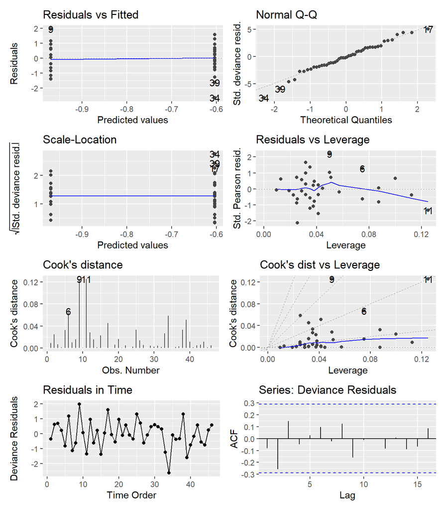

#### Proportion of intense storms

A change in the proportion of intense storms?

```
  SCUSUM Stat chpt Location       p-value
    0.1102272    19.0000000     0.6279521
```

The change in proportions occurs 1999 to 2000 with $p$-value 0.6279521.

In regime one, the proportion of intense storms is 0.1610169 (CI: 0.1051196, 0.238709) and in regime two, the proportion of intense storms is 0.2355072 (CI: 0.1891544, 0.2891682); a change of 0.0744903.

**Model Assessment**

The ratio of the residual deviance is 1.0672729.

The $p$-value for the Ljung-Box test on the deviance residuals 0.0898004.

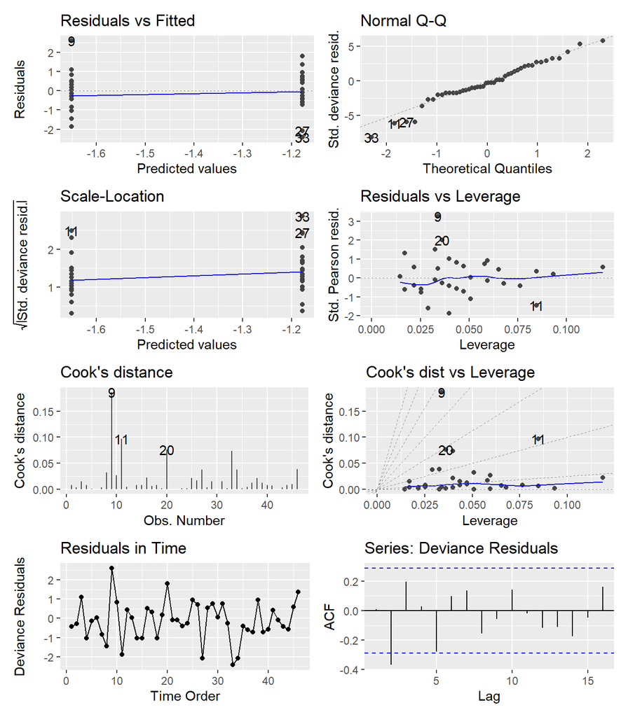

### Regression Methods

#### Poisson Regression on non-Shorties

```
Call:  glm(formula = Total_Storms ~ YearsSinceStart, family = poisson(link = "log"),
    data = storm_basin)

Coefficients:
    (Intercept)  YearsSinceStart
        1.68894          0.01899

Degrees of Freedom: 45 Total (i.e. Null);  44 Residual
Null Deviance:      80.4
Residual Deviance: 55.84    AIC: 238.8
```

```
Single term deletions

Model:
Total_Storms ~ YearsSinceStart
                Df Deviance    AIC    LRT  Pr(>Chi)
<none>               55.835 238.76
YearsSinceStart  1   80.400 261.32 24.565 7.184e-07 ***
---
Signif. codes:  0 '***' 0.001 '**' 0.01 '*' 0.05 '.' 0.1 ' ' 1
```

Using this model, in 1980 we would predict 5.4137639 storms (CI: 4.34858, 6.7398643) and in 2025 we predict 12.722063 storms (CI: 10.6707164, 15.167762).

That is a change of 1.5887607 storms per decade.

**Model Assessment**

The ratio of the residual deviance is 1.2689783.

The $p$-value for the Ljung-Box test on the deviance residuals 0.6424417.

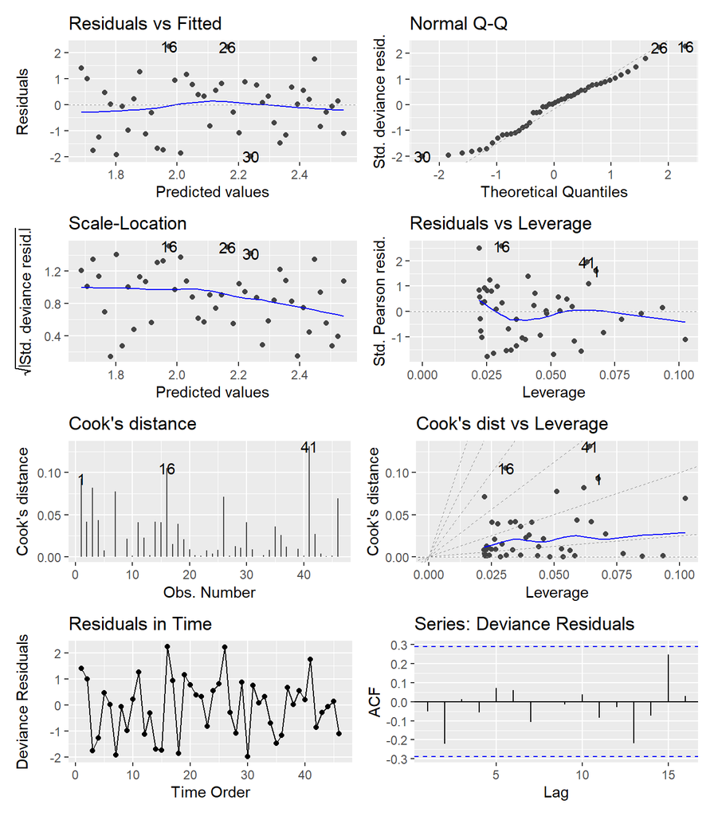

#### Poisson Regression on Hurricanes

```
Call:  glm(formula = Hurricanes ~ YearsSinceStart, family = poisson(link = "log"),
    data = storm_basin)

Coefficients:
    (Intercept)  YearsSinceStart
        1.51526          0.01389

Degrees of Freedom: 45 Total (i.e. Null);  44 Residual
Null Deviance:      64.93
Residual Deviance: 55.14    AIC: 224
```

```
Single term deletions

Model:
Hurricanes ~ YearsSinceStart
                Df Deviance    AIC    LRT Pr(>Chi)
<none>               55.135 223.96
YearsSinceStart  1   64.928 231.75 9.7926 0.001752 **
---
Signif. codes:  0 '***' 0.001 '**' 0.01 '*' 0.05 '.' 0.1 ' ' 1
```

Using this model, in 1980 we would predict 4.5506077 hurricanes (CI: 3.5568196, 5.8220638) and in 2025 we predict 8.5013344 hurricanes (CI: 6.8929109, 10.4850748).

That is a change of 0.8588536 hurricanes per decade.

**Model Assessment**

The ratio of the residual deviance is 1.2530694.

The $p$-value for the Ljung-Box test on the deviance residuals 0.6590301.

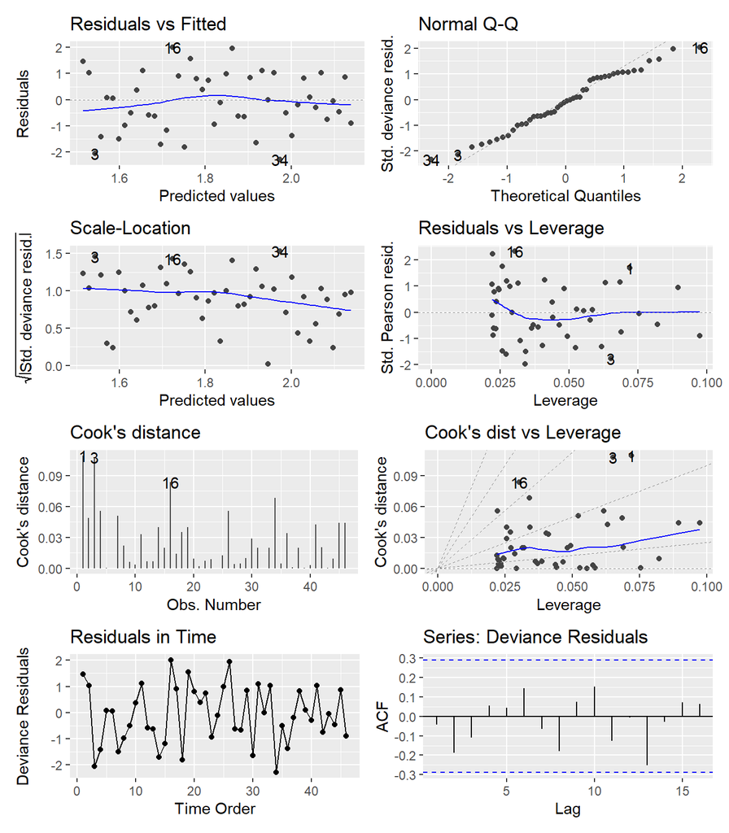

#### Poisson Regression on Major Storms

```
Call:  glm(formula = Major_Storms ~ YearsSinceStart, family = poisson(link = "log"),
    data = storm_basin)

Coefficients:
    (Intercept)  YearsSinceStart
        0.58920          0.01952

Degrees of Freedom: 45 Total (i.e. Null);  44 Residual
Null Deviance:      56.58
Residual Deviance: 47.83    AIC: 175.7
```

```
Single term deletions

Model:
Major_Storms ~ YearsSinceStart
                Df Deviance    AIC   LRT Pr(>Chi)
<none>               47.826 175.67
YearsSinceStart  1   56.580 182.43 8.754 0.003089 **
---
Signif. codes:  0 '***' 0.001 '**' 0.01 '*' 0.05 '.' 0.1 ' ' 1
```

Using this model, in 1980 we would predict 1.8025372 major storms (CI: 1.2345703, 2.6317986) and in 2025 we predict 4.3384651 major storms (CI: 3.2079581, 5.8673709).

That is a change of 0.5512887 major storms per decade.

**Model Assessment**

The ratio of the residual deviance is 1.0869576.

The $p$-value for the Ljung-Box test on the deviance residuals 0.4235062.

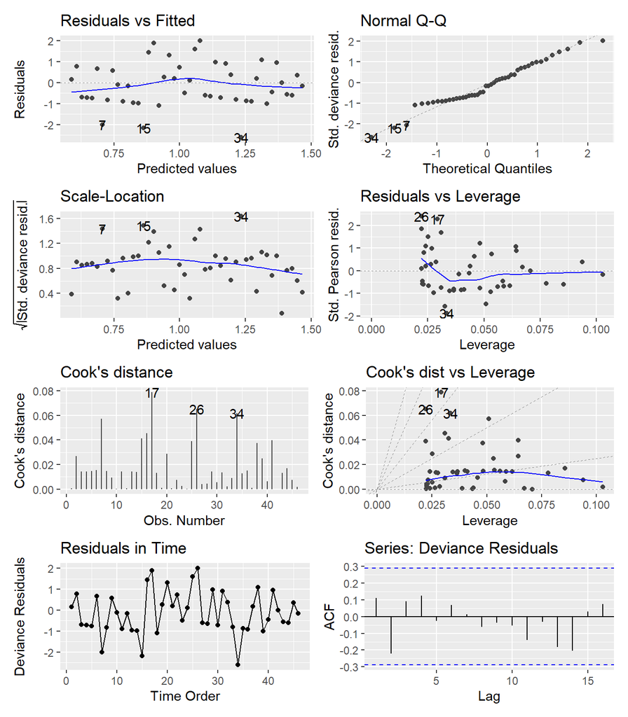

#### Poisson Regression on Intense Storms

```
Call:  glm(formula = Intense_Storms ~ YearsSinceStart, family = poisson(link = "log"),
    data = storm_basin)

Coefficients:
    (Intercept)  YearsSinceStart
       -0.07705          0.02730

Degrees of Freedom: 45 Total (i.e. Null);  44 Residual
Null Deviance:      65.66
Residual Deviance: 55.04    AIC: 153.7
```

```
Single term deletions

Model:
Intense_Storms ~ YearsSinceStart
                Df Deviance    AIC   LRT Pr(>Chi)
<none>               55.039 153.65
YearsSinceStart  1   65.659 162.27 10.62 0.001119 **
---
Signif. codes:  0 '***' 0.001 '**' 0.01 '*' 0.05 '.' 0.1 ' ' 1
```

Using this model, in 1980 we would predict 0.9258478 intense storms (CI: 0.5599028, 1.5309695) and in 2025 we predict 3.1634953 intense storms (CI: 2.1918624, 4.5658443).

That is a change of 0.4864451 intense storms per decade.

**Model Assessment**

The ratio of the residual deviance is 1.2508968.

The $p$-value for the Ljung-Box test on the deviance residuals 0.1015053.

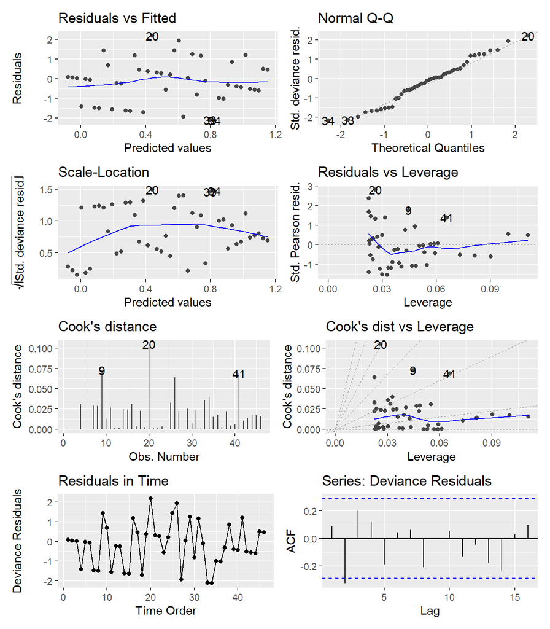

#### Logistic Regression on Proportions of Major

```
Call:  glm(formula = cbind(Major_Storms, Non_Major) ~ YearsSinceStart,
    family = binomial, data = prop_data)

Coefficients:
    (Intercept)  YearsSinceStart
      -0.695582         0.000829

Degrees of Freedom: 45 Total (i.e. Null);  44 Residual
Null Deviance:      38.57
Residual Deviance: 38.56    AIC: 147.1
```

```
Single term deletions

Model:
cbind(Major_Storms, Non_Major) ~ YearsSinceStart
                Df Deviance    AIC     LRT Pr(>Chi)
<none>               38.561 147.08
YearsSinceStart  1   38.571 145.09 0.00994   0.9206
```

Using this model, in 1980 the probability of a major storm in was 0.3327925 (CI: 0.2376061, 0.4439083) and in 2025 the probability of a major storm was 0.3411269 (CI: 0.2623368, 0.4297934).

That is a change of 0.181184 percent per decade.

**Model Assessment**

The ratio of the residual deviance is 0.8763911.

The $p$-value for the Ljung-Box test on the deviance residuals 0.4049638.

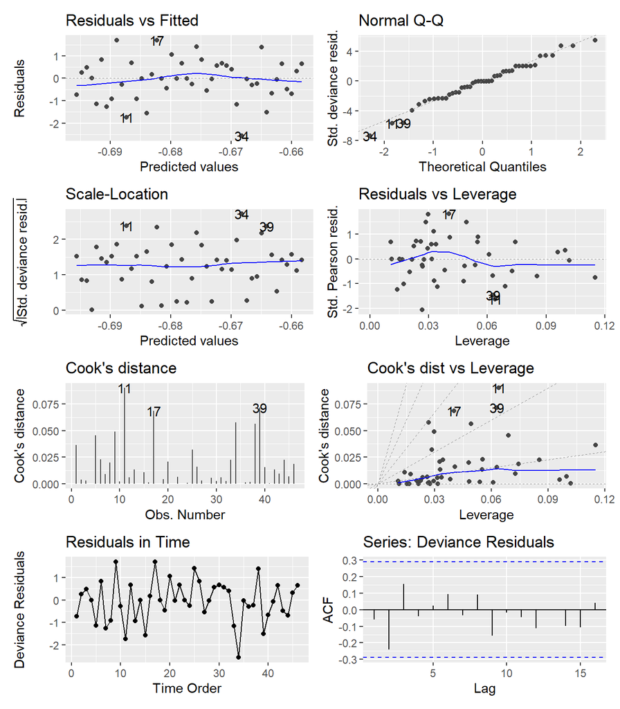

#### Logistic Regression on Proportions of Intense

```
Call:  glm(formula = cbind(Intense_Storms, Non_Intense) ~ YearsSinceStart,
    family = binomial, data = prop_data)

Coefficients:
    (Intercept)  YearsSinceStart
        -1.5925           0.0109

Degrees of Freedom: 45 Total (i.e. Null);  44 Residual
Null Deviance:      49.81
Residual Deviance: 48.55    AIC: 136.1
```

```
Single term deletions

Model:
cbind(Intense_Storms, Non_Intense) ~ YearsSinceStart
                Df Deviance    AIC   LRT Pr(>Chi)
<none>               48.546 136.06
YearsSinceStart  1   49.807 135.32 1.261   0.2615
```

Using this model, in 1980 the probability of a major storm in was 0.1690284 (CI: 0.1033836, 0.2640787) and in 2025 the probability of a major storm was 0.2493329 (CI: 0.1786207, 0.336568).

That is a change of 1.7457493 percent per decade.

**Model Assessment**

The ratio of the residual deviance is 1.103307.

The $p$-value for the Ljung-Box test on the deviance residuals 0.1368144.

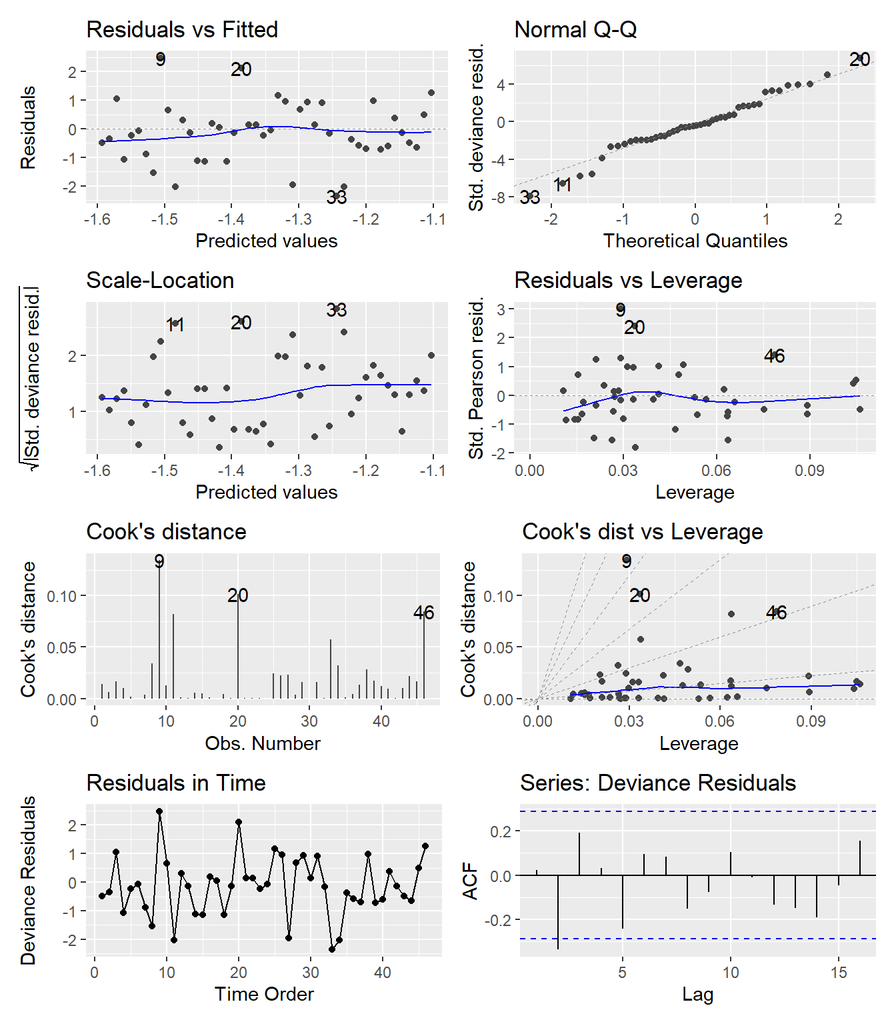

## HURSAT Quick Results

### Summary Statistics and Data

| Total Storms (Avg) | Total Storms (stddev) | Hurricanes (Avg) | Hurricanes (stddev) | Major Storms (Avg) | Major Storms (stddev) | Prop Major Storms | Intense Storms (Avg) | Intense Storms (stddev) | Prop Intense Storms |
| --- | --- | --- | --- | --- | --- | --- | --- | --- | --- |
| 4.295454 | 2.637648 | 4.022727 | 2.463582 | 2.75 | 1.881674 | 0.6402116 | 1.75 | 1.331636 | 0.4074074 |

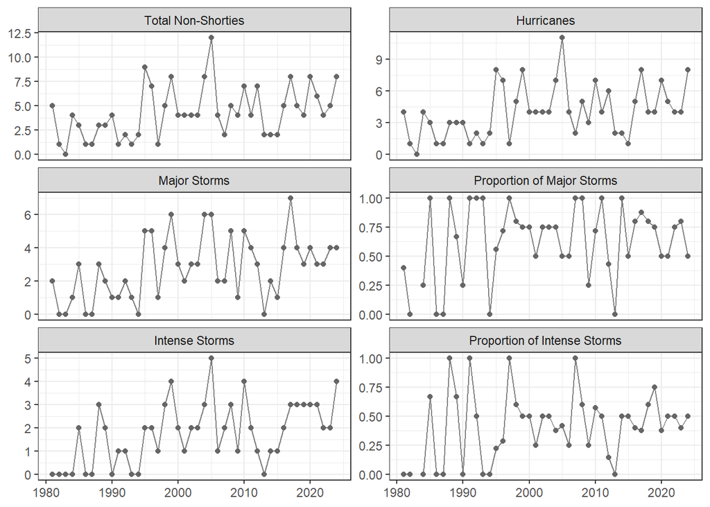

### Testing Results

**Changepoint Methods**

Here, we report the estimate mean for each segment or regime regardless of whether the test found a significant shift.

| Response | Chpt.Location | p.value | Regime1 | Regime2 | Change | Perc_Change |
| --- | --- | --- | --- | --- | --- | --- |
| Cyclone Freq | 1995 | 0.00051 | 2.21429 | 5.26667 | 3.05238 | 137.84946 |
| Hurricanes | 1995 | 0.00122 | 2.07143 | 4.93333 | 2.86190 | 138.16092 |
| Major Freq | 1995 | 0.00085 | 1.14286 | 3.50000 | 2.35714 | 206.25000 |
| Prop Major | 1988 | 0.03527 | 40.00000 | 66.09195 | 26.09195 | 65.22989 |
| Intense Freq | 1998 | 0.00106 | 0.82353 | 2.33333 | 1.50980 | 183.33333 |
| Prop Freq | 1988 | 0.08249 | 13.33333 | 43.10345 | 29.77011 | 223.27586 |

**Generalized Linear Model Approaches**

Note:

- we report the Likelihood Ratio Test for the generalized linear models, this is better to use than the default $Z$-test provided in the `summary()` output.
- the Change per decade is found by comparing the predicted value at the start time (1981) and end time (2024) and scaling by the number of years $\times 10$.

| Response | Coefficent | p.value | Start | End | Change per Decade |
| --- | --- | --- | --- | --- | --- |
| Cyclone Freq | 0.02016 | 0.00049 | 2.69541 | 6.41378 | 0.84508 |
| Hurricanes | 0.01927 | 0.00125 | 2.58029 | 5.90913 | 0.75656 |
| Major Freq | 0.02426 | 0.00084 | 1.55756 | 4.41982 | 0.65051 |
| Prop Major | 0.01253 | 0.32844 | 56.69885 | 69.18059 | 2.83676 |
| Intense Freq | 0.03144 | 0.00062 | 0.82290 | 3.18097 | 0.53592 |
| Prop Freq | 0.02098 | 0.09803 | 28.92506 | 50.07864 | 4.80763 |

## HURSAT Full Analysis

### Changepoint Methods

#### Change in Non-Shorty Counts

```
  SCUSUM Stat chpt Location       p-value
  1.302192652  14.000000000   0.000509523
```

The dates suggest the changepoint would occur from 1994 to 1995 with $p$-value 5.09523^{-4}.

In regime one, the mean number of storms is 2.2142857 (CI: 1.557222, 3.1485948) and in regime two, the mean number of storms is 5.2666667 (CI: 4.506264, 6.1553824); a change of 3.052381.

**Model Assessment**

The ratio of the residual deviance is 1.1775211.

The $p$-value for the Ljung-Box test on the deviance residuals 0.0487659.

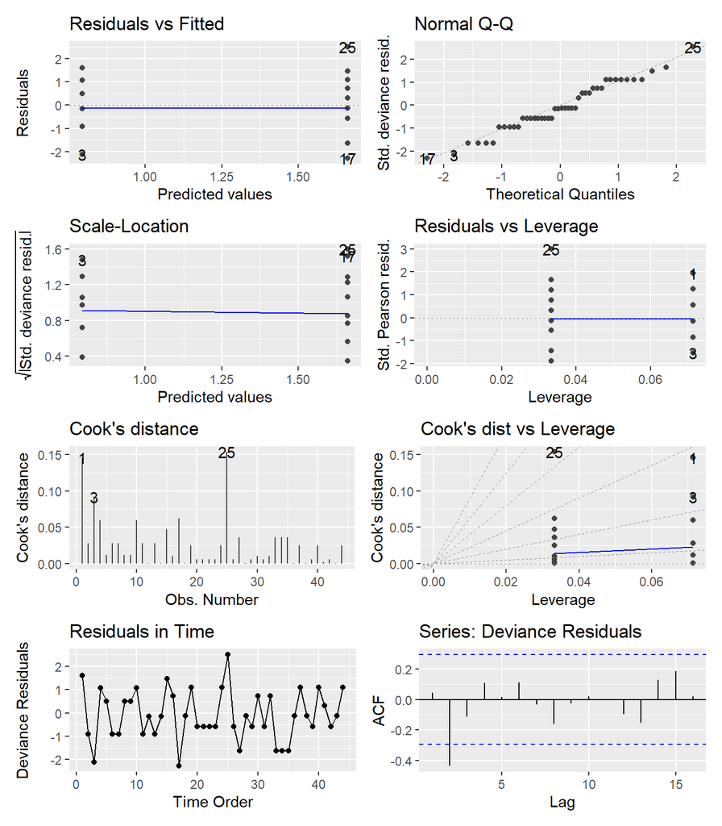

#### Change in counts of hurricanes

```
  SCUSUM Stat chpt Location       p-value
    1.1392221    14.0000000     0.0012175
```

The dates suggest the changepoint would occur from 1994 to 1995 with $p$-value 0.0012175.

In regime one, the mean number of hurricanes is 2.0714286 (CI: 1.4395013, 2.9807659) and in regime two, the mean number of hurricanes is 4.9333333 (CI: 4.1992472, 5.7957478); a change of 2.8619047.

**Model Assessment**

The ratio of the residual deviance is 1.0936877.

The $p$-value for the Ljung-Box test on the deviance residuals 0.080494.

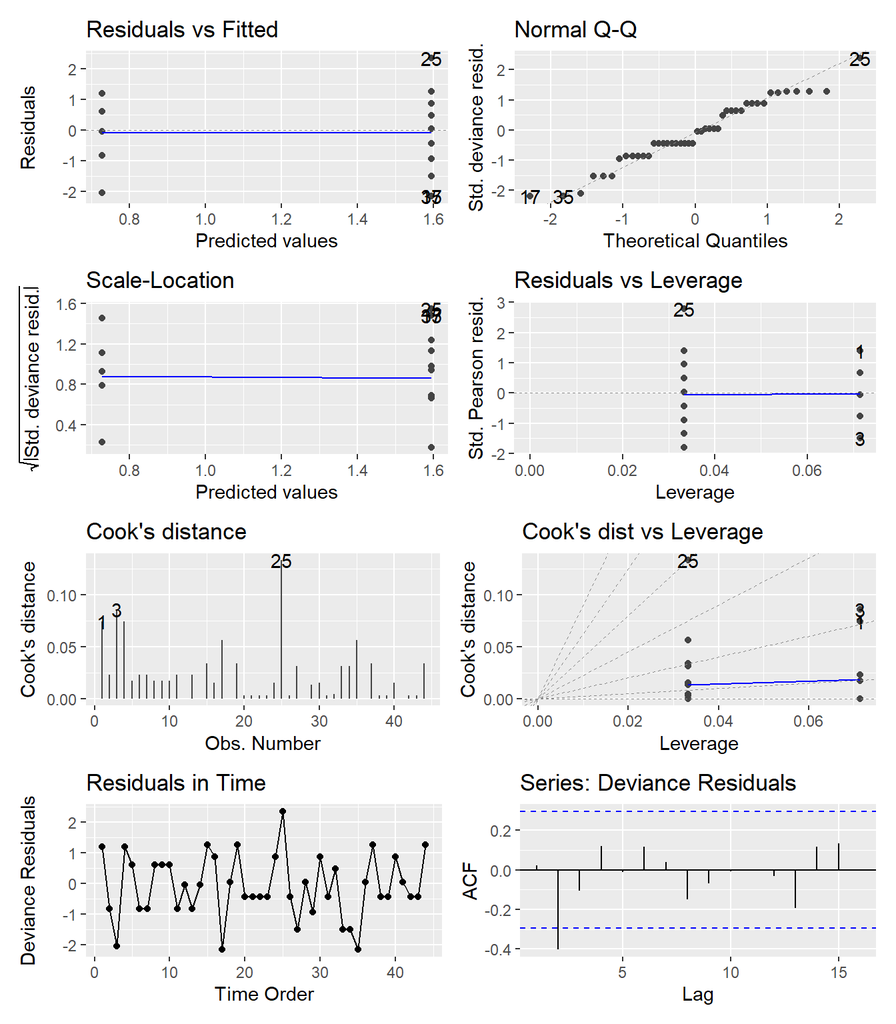

#### Change in counts of major storms

```
  SCUSUM Stat chpt Location       p-value
 1.205508e+00  1.400000e+01  8.533489e-04
```

The dates suggest the changepoint would occur from 1994 to 1995 with $p$-value 8.5334886^{-4}.

In regime one, the mean number of storms is 1.1428571 (CI: 0.7001451, 1.8655025) and in regime two, the mean number of storms is 3.5 (CI: 2.8906649, 4.2377793); a change of 2.3571429.

**Model Assessment**

The ratio of the residual deviance is 1.0746676.

The $p$-value for the Ljung-Box test on the deviance residuals 0.1281895.

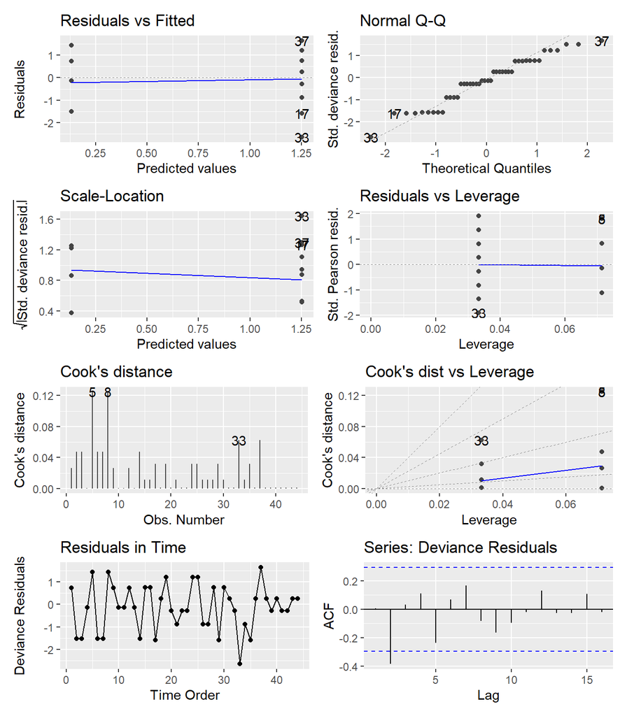

#### Change in counts of intense storms

```
  SCUSUM Stat chpt Location       p-value
  1.165621311  17.000000000   0.001056614
```

The dates suggest the changepoint would occur from 1997 to 1998 with $p$-value 0.0010566.

In regime one, the mean number of storms is 0.8235294 (CI: 0.4877392, 1.3904987) and in regime two, the mean number of storms is 2.3333333 (CI: 1.8227768, 2.9868958); a change of 1.5098039.

**Model Assessment**

The ratio of the residual deviance is 0.9675812.

The $p$-value for the Ljung-Box test on the deviance residuals 0.4084183.

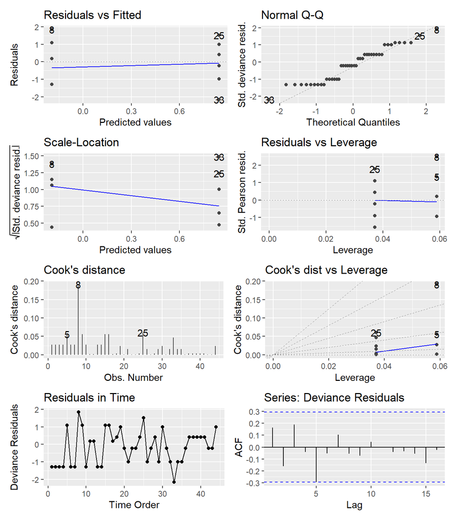

#### Proportion of major storms

A change in the proportion of major storms?

```
  SCUSUM Stat chpt Location       p-value
   0.53386696    7.00000000    0.03527181
```

The change in proportions occurs 1987 to 1988 with $p$-value 0.0352718.

In regime one, the proportion of major storms is 0.4 (CI: 0.1917815, 0.6519327) and in regime two, the proportion of major storms is 0.6609195 (CI: 0.587471, 0.7273599); a change of 0.2609195.

**Model Assessment**

The ratio of the residual deviance is 1.2879383.

The $p$-value for the Ljung-Box test on the deviance residuals 0.0184566.

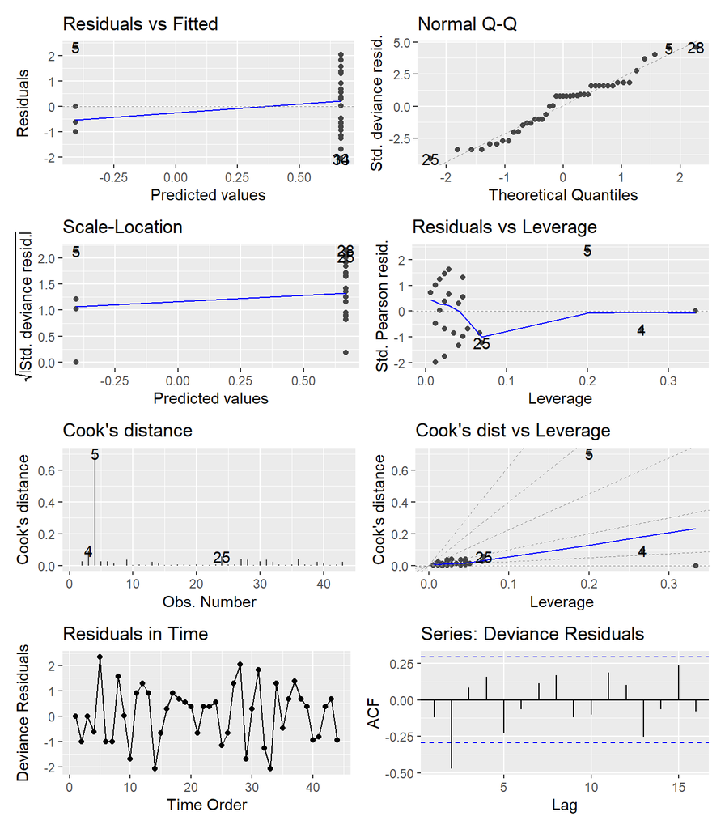

#### Proportion of intense storms

A change in the proportion of intense storms?

```
  SCUSUM Stat chpt Location       p-value
   0.39279737    7.00000000    0.08248868
```

The change in proportions occurs 1987 to 1988 with $p$-value 0.0824887.

In regime one, the proportion of intense storms is 0.1333333 (CI: 0.0335528, 0.4053803) and in regime two, the proportion of intense storms is 0.4310345 (CI: 0.359468, 0.5056024); a change of 0.2977011.

**Model Assessment**

The ratio of the residual deviance is 1.0385469.

The $p$-value for the Ljung-Box test on the deviance residuals 0.2316439.

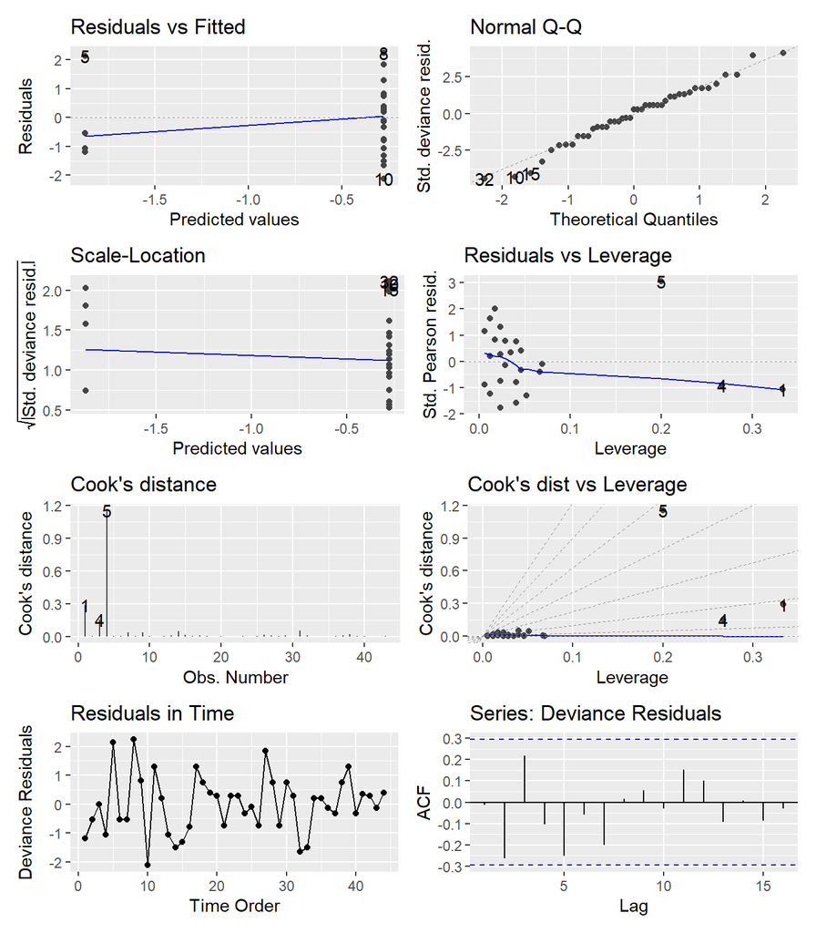

### Regression Methods

#### Poisson Regression on non-Shorties

```
Call:  glm(formula = Total_Storms ~ YearsSinceStart, family = poisson(link = "log"),
    data = storm_basin)

Coefficients:
    (Intercept)  YearsSinceStart
        0.99155          0.02016

Degrees of Freedom: 43 Total (i.e. Null);  42 Residual
Null Deviance:      72.79
Residual Deviance: 60.64    AIC: 201.3
```

```
Single term deletions

Model:
Total_Storms ~ YearsSinceStart
                Df Deviance    AIC    LRT  Pr(>Chi)
<none>               60.638 201.26
YearsSinceStart  1   72.787 211.41 12.148 0.0004914 ***
---
Signif. codes:  0 '***' 0.001 '**' 0.01 '*' 0.05 '.' 0.1 ' ' 1
```

Using this model, in 1981 we would predict 2.695413 storms (CI: 1.9636166, 3.6999337) and in 2024 we predict 6.4137825 storms (CI: 4.9784974, 8.2628559).

That is a change of 0.845084 storms per decade.

**Model Assessment**

The ratio of the residual deviance is 1.4437737.

The $p$-value for the Ljung-Box test on the deviance residuals 0.1888648.

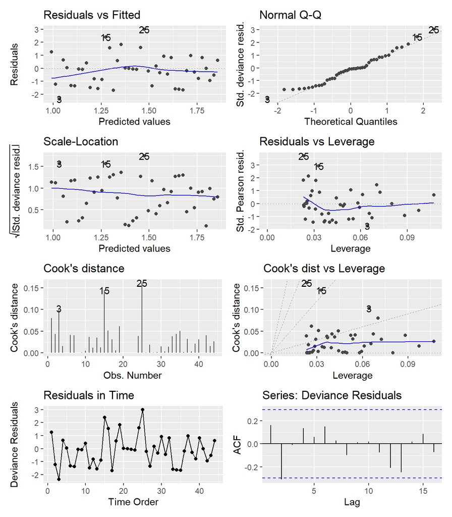

#### Poisson Regression on Hurricanes

```
Call:  glm(formula = Hurricanes ~ YearsSinceStart, family = poisson(link = "log"),
    data = storm_basin)

Coefficients:
    (Intercept)  YearsSinceStart
        0.94790          0.01927

Degrees of Freedom: 43 Total (i.e. Null);  42 Residual
Null Deviance:      67.84
Residual Deviance: 57.43    AIC: 195.5
```

```
Single term deletions

Model:
Hurricanes ~ YearsSinceStart
                Df Deviance    AIC    LRT Pr(>Chi)
<none>               57.428 195.46
YearsSinceStart  1   67.839 203.87 10.411 0.001253 **
---
Signif. codes:  0 '***' 0.001 '**' 0.01 '*' 0.05 '.' 0.1 ' ' 1
```

Using this model, in 1981 we would predict 2.5802868 hurricanes (CI: 1.8635201, 3.5727437) and in 2024 we predict 5.9091309 hurricanes (CI: 4.5434057, 7.6853863).

That is a change of 0.7565555 hurricanes per decade.

**Model Assessment**

The ratio of the residual deviance is 1.3673394.

The $p$-value for the Ljung-Box test on the deviance residuals 0.2692919.

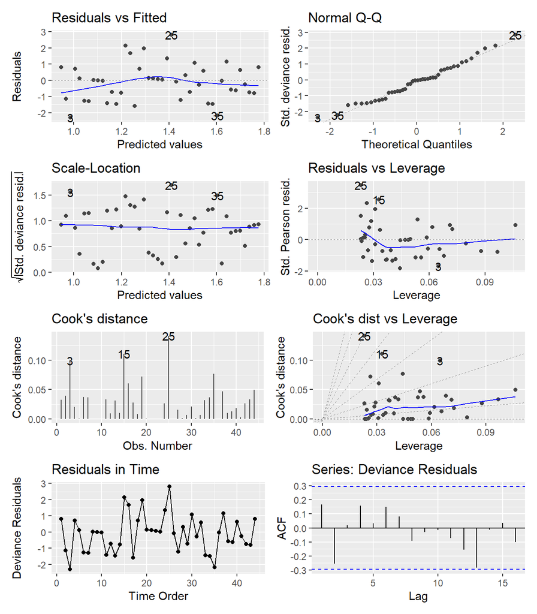

#### Poisson Regression on Major Storms

```
Call:  glm(formula = Major_Storms ~ YearsSinceStart, family = poisson(link = "log"),
    data = storm_basin)

Coefficients:
    (Intercept)  YearsSinceStart
        0.44312          0.02426

Degrees of Freedom: 43 Total (i.e. Null);  42 Residual
Null Deviance:      67.68
Residual Deviance: 56.52    AIC: 171.3
```

```
Single term deletions

Model:
Major_Storms ~ YearsSinceStart
                Df Deviance    AIC    LRT  Pr(>Chi)
<none>               56.520 171.31
YearsSinceStart  1   67.682 180.47 11.161 0.0008352 ***
---
Signif. codes:  0 '***' 0.001 '**' 0.01 '*' 0.05 '.' 0.1 ' ' 1
```

Using this model, in 1981 we would predict 1.5575606 major storms (CI: 1.0370332, 2.3393612) and in 2024 we predict 4.4198212 major storms (CI: 3.2385601, 6.031946).

That is a change of 0.6505138 major storms per decade.

**Model Assessment**

The ratio of the residual deviance is 1.3457249.

The $p$-value for the Ljung-Box test on the deviance residuals 0.301307.

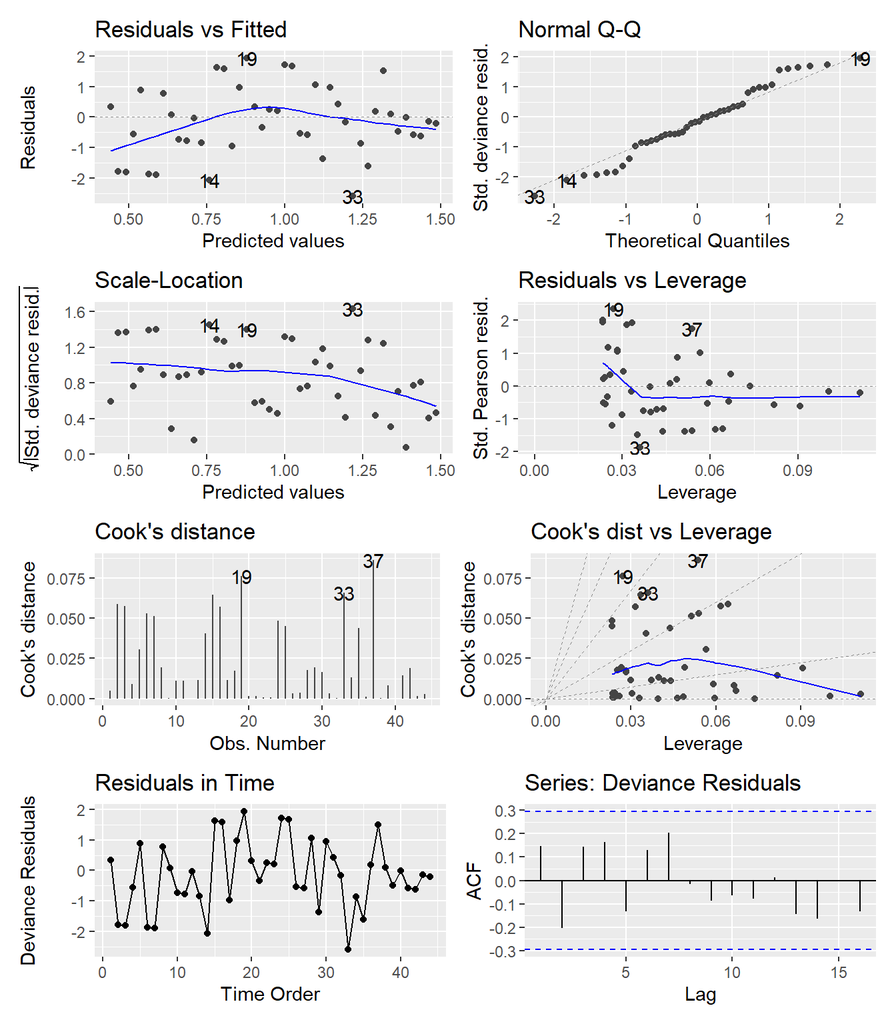

#### Poisson Regression on Intense Storms

```
Call:  glm(formula = Intense_Storms ~ YearsSinceStart, family = poisson(link = "log"),
    data = storm_basin)

Coefficients:
    (Intercept)  YearsSinceStart
       -0.19492          0.03144

Degrees of Freedom: 43 Total (i.e. Null);  42 Residual
Null Deviance:      55.78
Residual Deviance: 44.06    AIC: 137.6
```

```
Single term deletions

Model:
Intense_Storms ~ YearsSinceStart
                Df Deviance    AIC    LRT  Pr(>Chi)
<none>               44.064 137.63
YearsSinceStart  1   55.781 147.35 11.717 0.0006193 ***
---
Signif. codes:  0 '***' 0.001 '**' 0.01 '*' 0.05 '.' 0.1 ' ' 1
```

Using this model, in 1981 we would predict 0.8229014 intense storms (CI: 0.4816625, 1.4058948) and in 2024 we predict 3.1809678 intense storms (CI: 2.1785057, 4.6447233).

That is a change of 0.5359242 intense storms per decade.

**Model Assessment**

The ratio of the residual deviance is 1.049136.

The $p$-value for the Ljung-Box test on the deviance residuals 0.2437882.

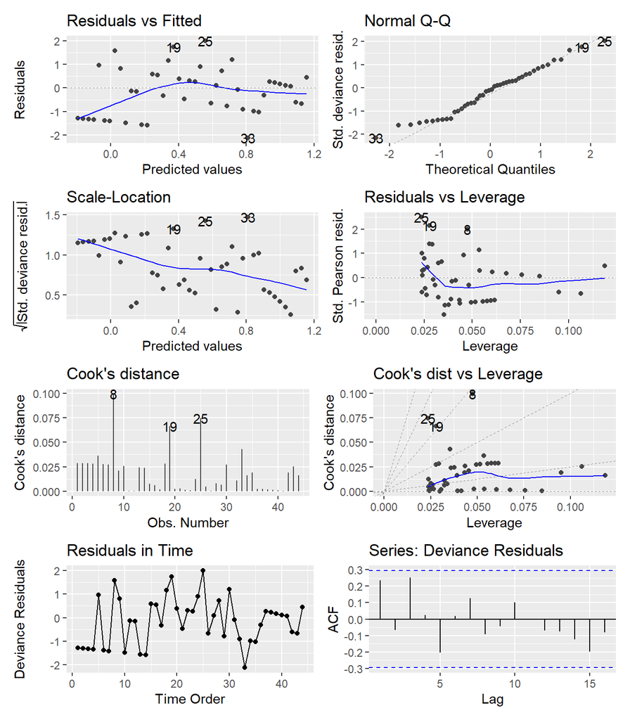

#### Logistic Regression on Proportions of Major

```
Call:  glm(formula = cbind(Major_Storms, Non_Major) ~ YearsSinceStart,
    family = binomial, data = prop_data)

Coefficients:
    (Intercept)  YearsSinceStart
        0.26957          0.01253

Degrees of Freedom: 42 Total (i.e. Null);  41 Residual
Null Deviance:      56.69
Residual Deviance: 55.74    AIC: 116.5
```

```
Single term deletions

Model:
cbind(Major_Storms, Non_Major) ~ YearsSinceStart
                Df Deviance    AIC     LRT Pr(>Chi)
<none>               55.739 116.49
YearsSinceStart  1   56.694 115.44 0.95506   0.3284
```

Using this model, in 1981 the probability of a major storm in was 0.5669885 (CI: 0.3991027, 0.7207842) and in 2024 the probability of a major storm was 0.6918059 (CI: 0.5622121, 0.7968961).

That is a change of 2.8367586 percent per decade.

**Model Assessment**

The ratio of the residual deviance is 1.359479.

The $p$-value for the Ljung-Box test on the deviance residuals 0.0593161.

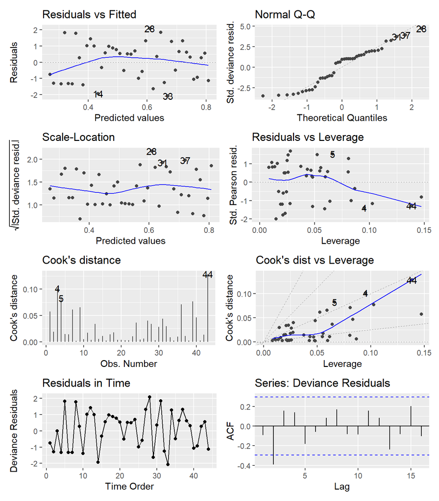

#### Logistic Regression on Proportions of Intense

```
Call:  glm(formula = cbind(Intense_Storms, Non_Intense) ~ YearsSinceStart,
    family = binomial, data = prop_data)

Coefficients:
    (Intercept)  YearsSinceStart
       -0.89903          0.02098

Degrees of Freedom: 42 Total (i.e. Null);  41 Residual
Null Deviance:      48.4
Residual Deviance: 45.66    AIC: 111.4
```

```
Single term deletions

Model:
cbind(Intense_Storms, Non_Intense) ~ YearsSinceStart
                Df Deviance    AIC    LRT Pr(>Chi)
<none>               45.659 111.42
YearsSinceStart  1   48.396 112.16 2.7373  0.09803 .
---
Signif. codes:  0 '***' 0.001 '**' 0.01 '*' 0.05 '.' 0.1 ' ' 1
```

Using this model, in 1981 the probability of a major storm in was 0.2892506 (CI: 0.1683085, 0.4500695) and in 2024 the probability of a major storm was 0.5007864 (CI: 0.3707506, 0.6307158).

That is a change of 4.8076318 percent per decade.

**Model Assessment**

The ratio of the residual deviance is 1.1136383.

The $p$-value for the Ljung-Box test on the deviance residuals 0.1999483.

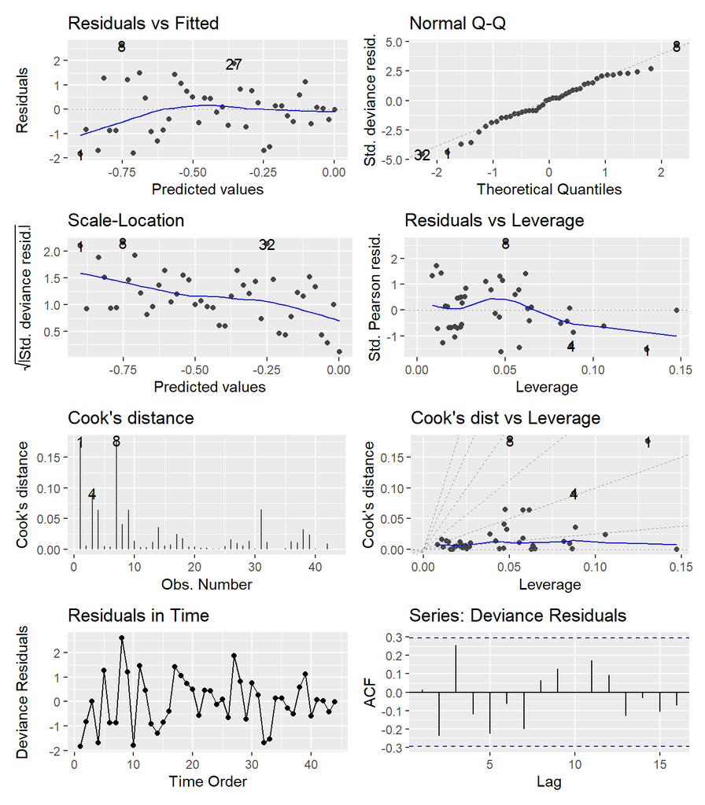

# Eastern North Pacific

## IBTrACS Quick Results

### Summary Statistics and Data

| Total Storms (Avg) | Total Storms (stddev) | Hurricanes (Avg) | Hurricanes (stddev) | Major Storms (Avg) | Major Storms (stddev) | Prop Major Storms | Intense Storms (Avg) | Intense Storms (stddev) | Prop Intense Storms |
| --- | --- | --- | --- | --- | --- | --- | --- | --- | --- |
| 10.43478 | 3.885312 | 8.478261 | 3.338257 | 4.543478 | 2.73826 | 0.4354167 | 3.152174 | 2.485222 | 0.3020833 |

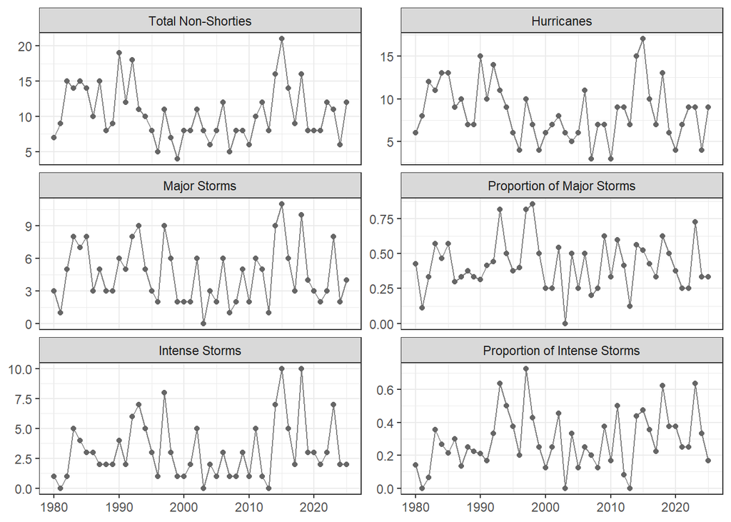

### Testing Results

**Changepoint Methods**

Here, we report the estimate mean for each segment or regime regardless of whether the test found a significant shift.

| Response | Chpt.Location | p.value | Regime1 | Regime2 | Change | Perc_Change |
| --- | --- | --- | --- | --- | --- | --- |
| Cyclone Freq | 1995 | 0.09564 | 12.57143 | 9.50000 | -3.07143 | -24.43182 |
| Hurricanes | 1996 | 0.07511 | 10.33333 | 7.58065 | -2.75269 | -26.63892 |
| Major Freq | 2000 | 0.40339 | 5.21053 | 4.07407 | -1.13645 | -21.81070 |
| Prop Major | 2001 | 0.66905 | 45.70136 | 41.69884 | -4.00252 | -8.75798 |
| Intense Freq | 2015 | 0.09587 | 2.61765 | 4.66667 | 2.04902 | 78.27715 |
| Prop Freq | 1993 | 0.11409 | 19.72789 | 34.83483 | 15.10694 | 76.57658 |

**Generalized Linear Model Approaches**

Note:

- we report the Likelihood Ratio Test for the generalized linear models, this is better to use than the default $Z$-test provided in the `summary()` output.
- the Change per decade is found by comparing the predicted value at the start time (1980) and end time (2025) and scaling by the number of years $\times 10$.

| Response | Coefficent | p.value | Start | End | Change per Decade |
| --- | --- | --- | --- | --- | --- |
| Cyclone Freq | -0.00313 | 0.36221 | 11.18734 | 9.71602 | -0.31985 |
| Hurricanes | -0.00549 | 0.15034 | 9.56763 | 7.47314 | -0.45533 |
| Major Freq | -0.00186 | 0.72115 | 4.73619 | 4.35595 | -0.08266 |
| Prop Major | 0.00210 | 0.75362 | 42.41021 | 44.73458 | 0.50530 |
| Intense Freq | 0.00960 | 0.12585 | 2.51942 | 3.88043 | 0.29587 |
| Prop Freq | 0.01706 | 0.01882 | 22.74618 | 38.81853 | 3.49399 |

## IBTrACS Full Analysis

### Changepoint Methods

#### Change in Non-Shorty Counts

```
  SCUSUM Stat chpt Location       p-value
   0.36912610   14.00000000    0.09563624
```

The dates suggest the changepoint would occur from 1994 to 1995 with $p$-value 0.0956362.

In regime one, the mean number of storms is 12.5714286 (CI: 10.8448046, 14.5729519) and in regime two, the mean number of storms is 9.5 (CI: 8.4899083, 10.6302679); a change of -3.0714286.

**Model Assessment**

The ratio of the residual deviance is 1.2351125.

The $p$-value for the Ljung-Box test on the deviance residuals 0.4339259.

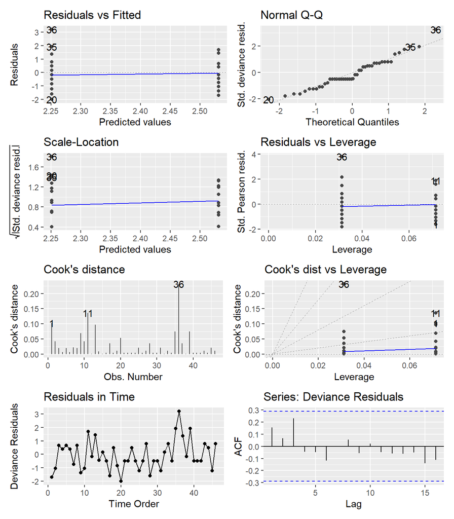

#### Change in counts of hurricanes

```
  SCUSUM Stat chpt Location       p-value
   0.40795647   15.00000000    0.07510751
```

The dates suggest the changepoint would occur from 1995 to 1996 with $p$-value 0.0751075.

In regime one, the mean number of hurricanes is 10.3333333 (CI: 8.8281364, 12.0951663) and in regime two, the mean number of hurricanes is 7.5806452 (CI: 6.6708172, 8.614564); a change of -2.7526882.

**Model Assessment**

The ratio of the residual deviance is 1.1387063.

The $p$-value for the Ljung-Box test on the deviance residuals 0.5234726.

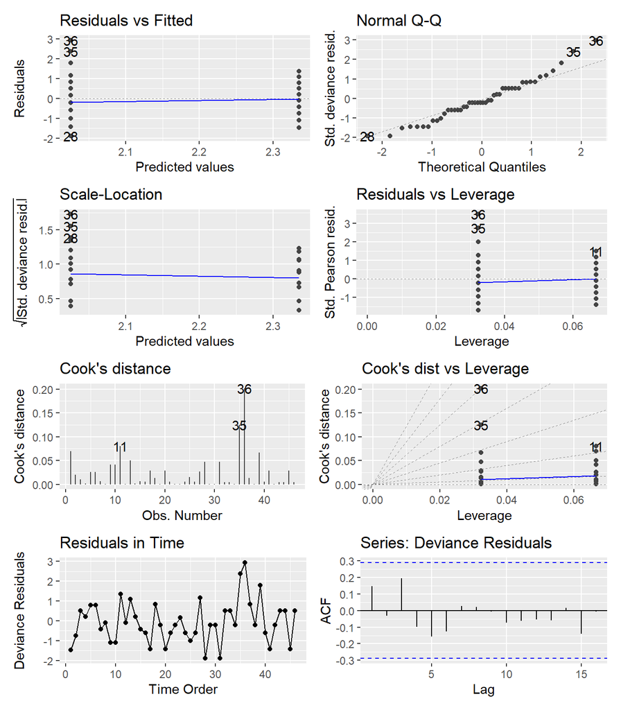

#### Change in counts of major storms

```
  SCUSUM Stat chpt Location       p-value
    0.1613193    19.0000000     0.4033939
```

The dates suggest the changepoint would occur from 1999 to 2000 with $p$-value 0.4033939.

In regime one, the mean number of storms is 5.2105263 (CI: 4.2788893, 6.3450075) and in regime two, the mean number of storms is 4.0740741 (CI: 3.3796253, 4.9112189); a change of -1.1364522.

**Model Assessment**

The ratio of the residual deviance is 1.6808675.

The $p$-value for the Ljung-Box test on the deviance residuals 0.9479538.

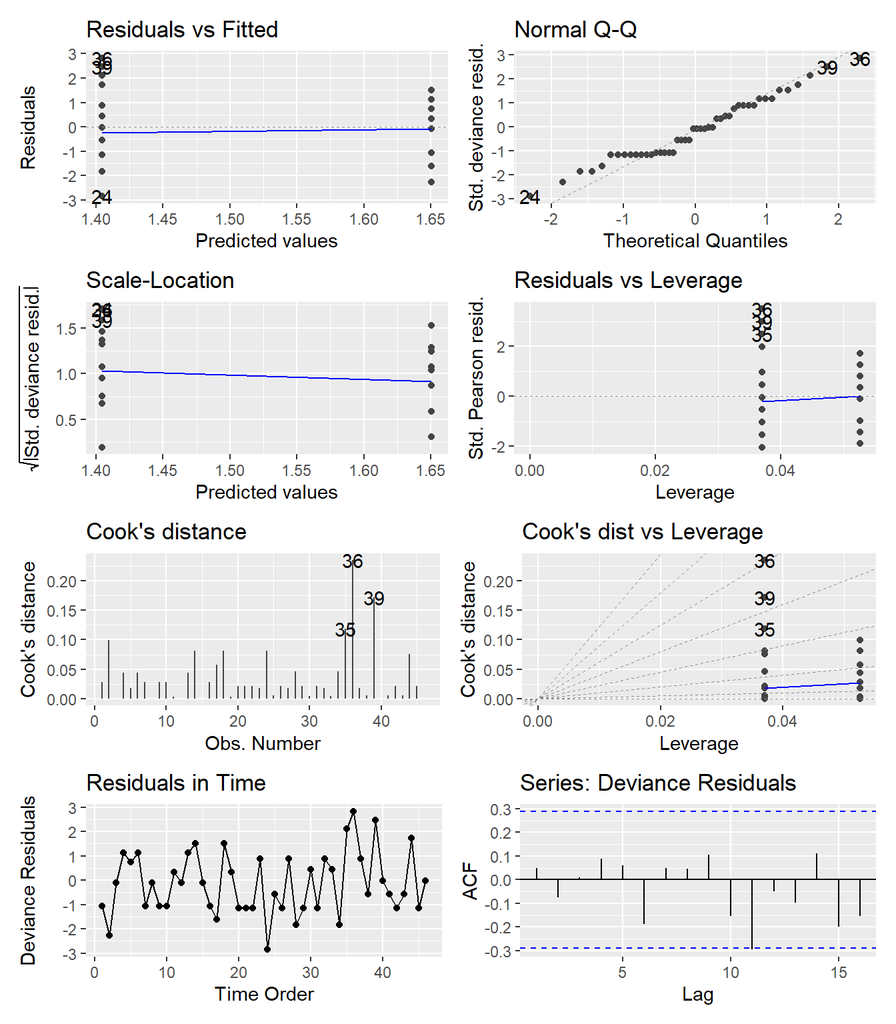

#### Change in counts of intense storms

```
  SCUSUM Stat chpt Location       p-value
   0.36873248   34.00000000    0.09587332
```

The dates suggest the changepoint would occur from 2014 to 2015 with $p$-value 0.0958733.

In regime one, the mean number of storms is 2.6176471 (CI: 2.1265826, 3.2221067) and in regime two, the mean number of storms is 4.6666667 (CI: 3.591353, 6.0639479); a change of 2.0490196.

**Model Assessment**

The ratio of the residual deviance is 1.6930095.

The $p$-value for the Ljung-Box test on the deviance residuals 0.5892544.

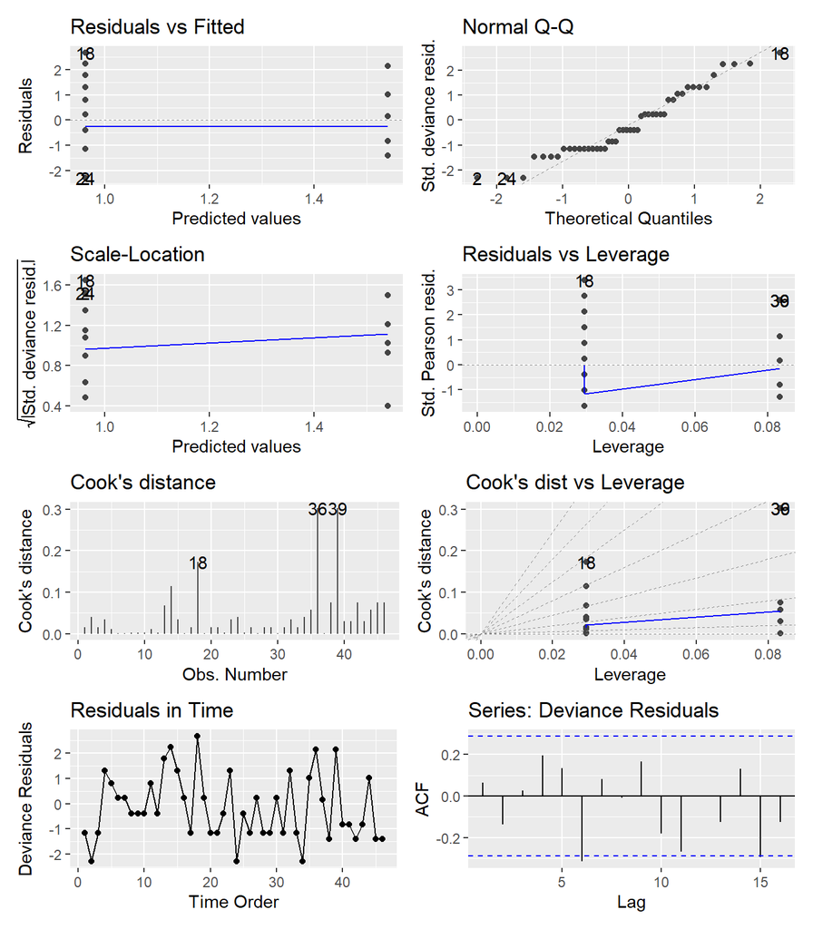

#### Proportion of major storms

A change in the proportion of major storms?

```
  SCUSUM Stat chpt Location       p-value
   0.07945922   20.00000000    0.66904672
```

The change in proportions occurs 2000 to 2001 with $p$-value 0.6690467.

In regime one, the proportion of major storms is 0.4570136 (CI: 0.3924468, 0.5230577) and in regime two, the proportion of major storms is 0.4169884 (CI: 0.3584372, 0.4779783); a change of -0.0400252.

**Model Assessment**

The ratio of the residual deviance is 1.4422941.

The $p$-value for the Ljung-Box test on the deviance residuals 0.8316138.

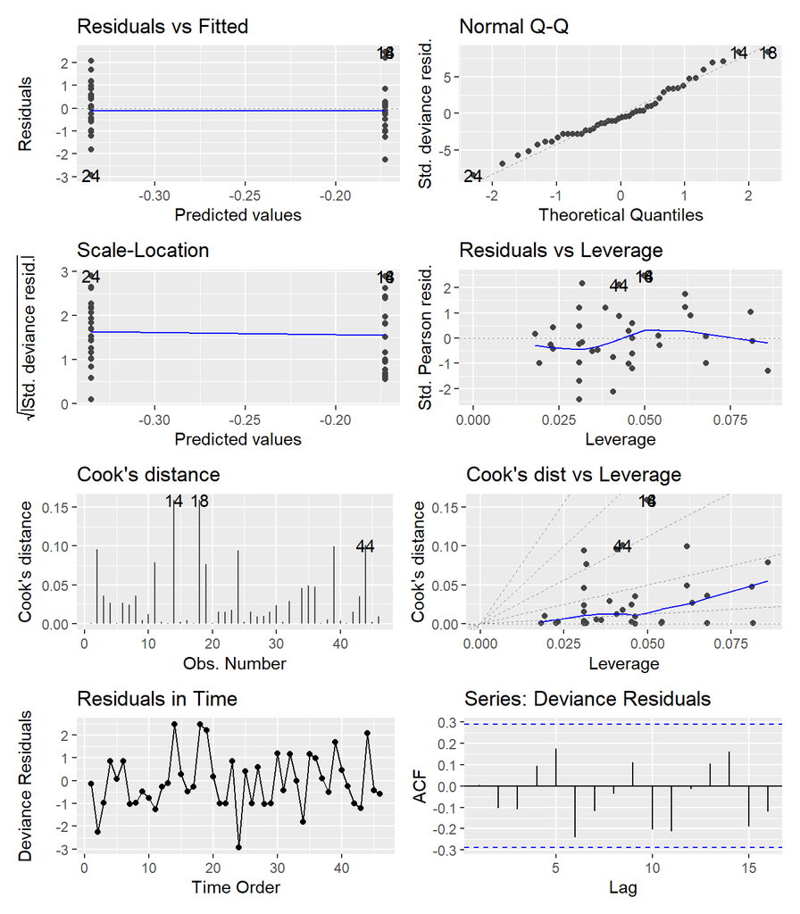

#### Proportion of intense storms

A change in the proportion of intense storms?

```
  SCUSUM Stat chpt Location       p-value
    0.3413084    12.0000000     0.1140917
```

The change in proportions occurs 1992 to 1993 with $p$-value 0.1140917.

In regime one, the proportion of intense storms is 0.1972789 (CI: 0.1406839, 0.2695009) and in regime two, the proportion of intense storms is 0.3483483 (CI: 0.2990677, 0.4011026); a change of 0.1510694.

**Model Assessment**

The ratio of the residual deviance is 1.4771258.

The $p$-value for the Ljung-Box test on the deviance residuals 0.5907774.

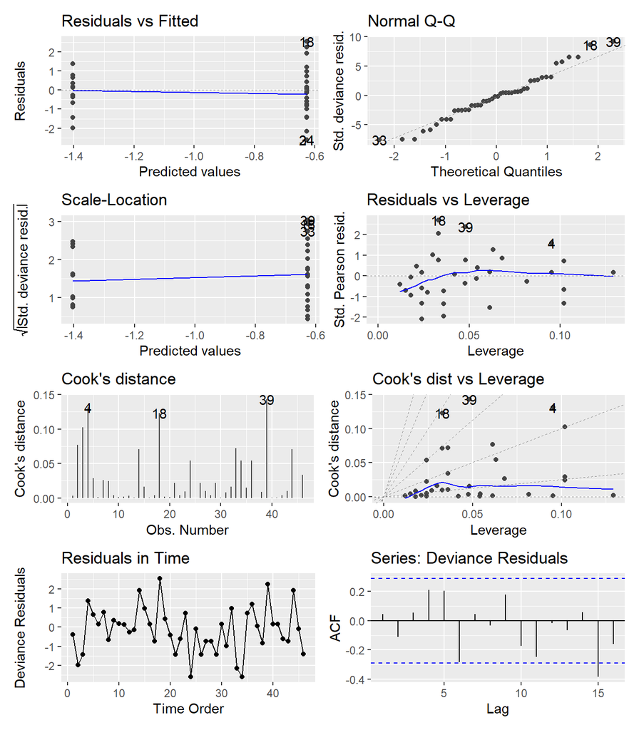

### Regression Methods

#### Poisson Regression on non-Shorties

```
Call:  glm(formula = Total_Storms ~ YearsSinceStart, family = poisson(link = "log"),
    data = storm_basin)

Coefficients:
    (Intercept)  YearsSinceStart
       2.414783        -0.003133

Degrees of Freedom: 45 Total (i.e. Null);  44 Residual
Null Deviance:      62.85
Residual Deviance: 62.02    AIC: 256.2
```

```
Single term deletions

Model:
Total_Storms ~ YearsSinceStart
                Df Deviance    AIC     LRT Pr(>Chi)
<none>               62.023 256.21
YearsSinceStart  1   62.854 255.04 0.83023   0.3622
```

Using this model, in 1980 we would predict 11.1873394 storms (CI: 9.41088, 13.2991349) and in 2025 we predict 9.7160237 storms (CI: 8.1209589, 11.6243806).

That is a change of -0.3198512 storms per decade.

**Model Assessment**

The ratio of the residual deviance is 1.4096228.

The $p$-value for the Ljung-Box test on the deviance residuals 0.0964992.

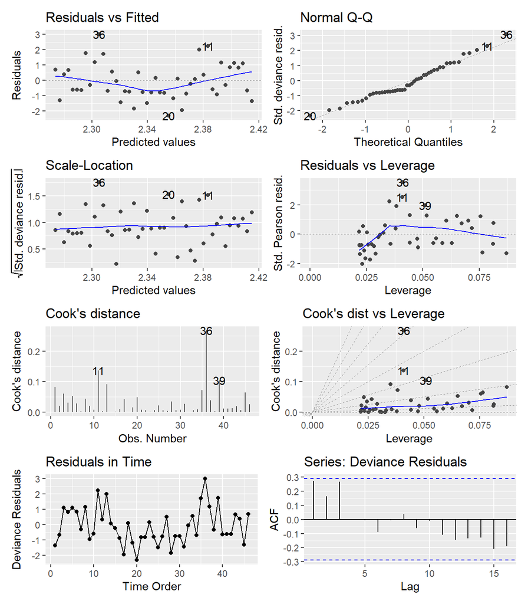

#### Poisson Regression on Hurricanes

```
Call:  glm(formula = Hurricanes ~ YearsSinceStart, family = poisson(link = "log"),
    data = storm_basin)

Coefficients:
    (Intercept)  YearsSinceStart
        2.25839         -0.00549

Degrees of Freedom: 45 Total (i.e. Null);  44 Residual
Null Deviance:      58.85
Residual Deviance: 56.78    AIC: 241
```

```
Single term deletions

Model:
Hurricanes ~ YearsSinceStart
                Df Deviance    AIC    LRT Pr(>Chi)
<none>               56.778 241.02
YearsSinceStart  1   58.846 241.09 2.0688   0.1503
```

Using this model, in 1980 we would predict 9.5676313 hurricanes (CI: 7.9173119, 11.5619506) and in 2025 we predict 7.4731362 hurricanes (CI: 6.1074583, 9.144191).

That is a change of -0.455325 hurricanes per decade.

**Model Assessment**

The ratio of the residual deviance is 1.2903985.

The $p$-value for the Ljung-Box test on the deviance residuals 0.2268969.

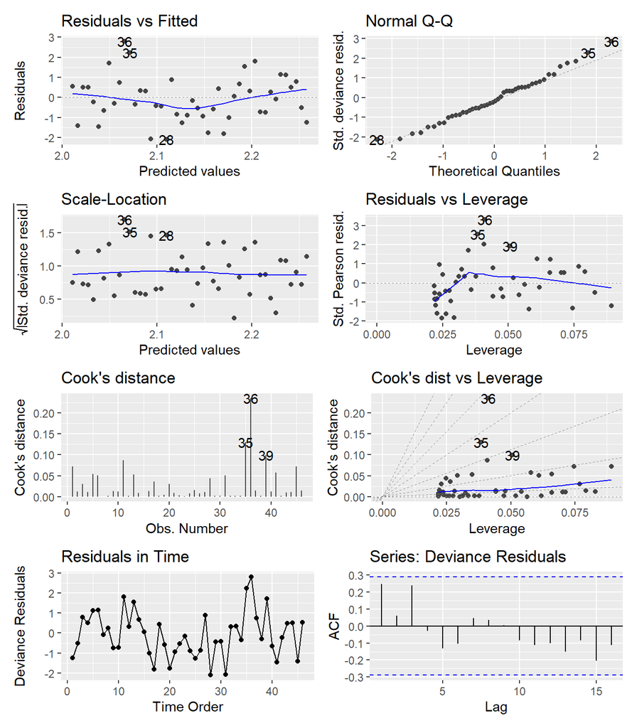

#### Poisson Regression on Major Storms

```
Call:  glm(formula = Major_Storms ~ YearsSinceStart, family = poisson(link = "log"),
    data = storm_basin)

Coefficients:
    (Intercept)  YearsSinceStart
        1.55523         -0.00186

Degrees of Freedom: 45 Total (i.e. Null);  44 Residual
Null Deviance:      77.09
Residual Deviance: 76.96    AIC: 226.9
```

```
Single term deletions

Model:
Major_Storms ~ YearsSinceStart
                Df Deviance    AIC     LRT Pr(>Chi)
<none>               76.964 226.90
YearsSinceStart  1   77.091 225.03 0.12739   0.7212
```

Using this model, in 1980 we would predict 4.7361935 major storms (CI: 3.6374587, 6.1668133) and in 2025 we predict 4.3559485 major storms (CI: 3.3261896, 5.7045117).

That is a change of -0.082662 major storms per decade.

**Model Assessment**

The ratio of the residual deviance is 1.7491716.

The $p$-value for the Ljung-Box test on the deviance residuals 0.8983663.

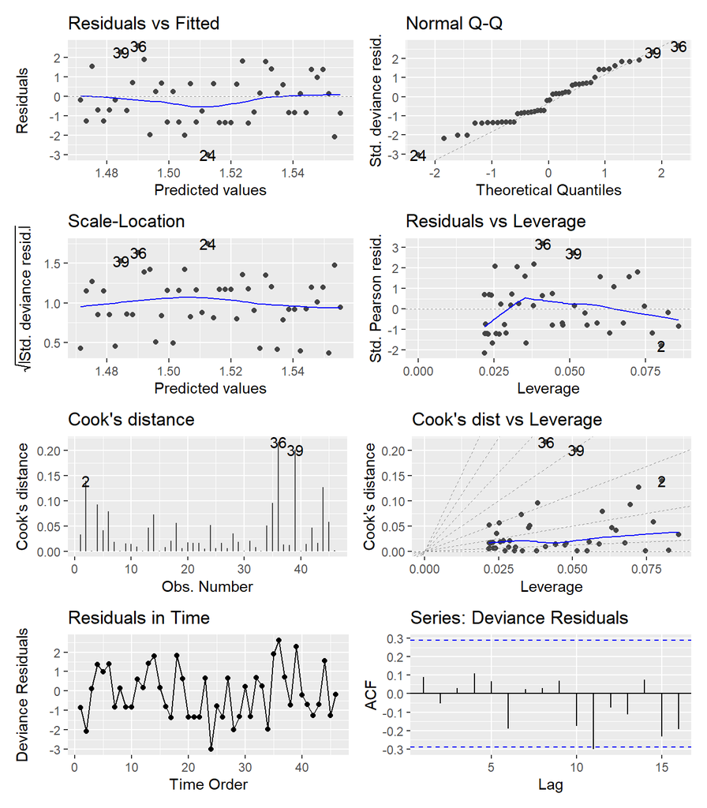

#### Poisson Regression on Intense Storms

```
Call:  glm(formula = Intense_Storms ~ YearsSinceStart, family = poisson(link = "log"),
    data = storm_basin)

Coefficients:
    (Intercept)  YearsSinceStart
       0.924028         0.009598

Degrees of Freedom: 45 Total (i.e. Null);  44 Residual
Null Deviance:      85.36
Residual Deviance: 83.02    AIC: 211.3
```

```
Single term deletions

Model:
Intense_Storms ~ YearsSinceStart
                Df Deviance    AIC   LRT Pr(>Chi)
<none>               83.018 211.35
YearsSinceStart  1   85.361 211.69 2.343   0.1259
```

Using this model, in 1980 we would predict 2.5194177 intense storms (CI: 1.7940763, 3.538013) and in 2025 we predict 3.8804307 intense storms (CI: 2.8639976, 5.257596).

That is a change of 0.2958724 intense storms per decade.

**Model Assessment**

The ratio of the residual deviance is 1.8867643.

The $p$-value for the Ljung-Box test on the deviance residuals 0.5472507.

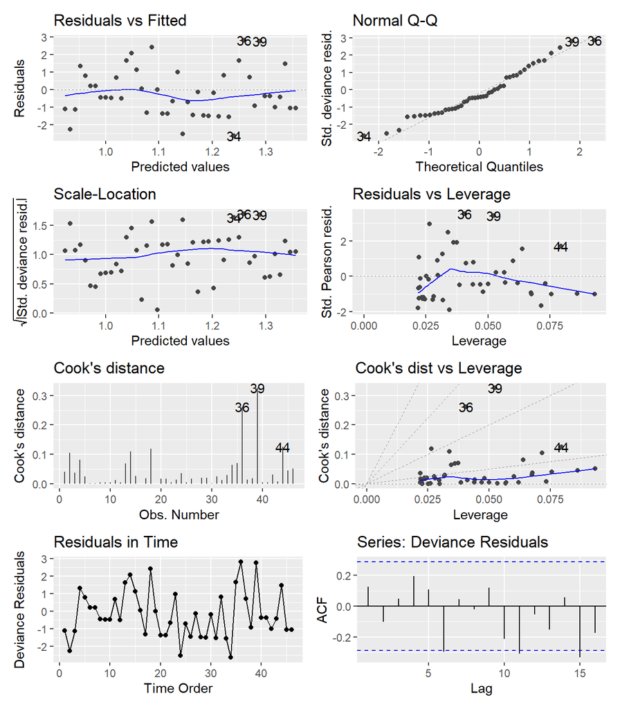

#### Logistic Regression on Proportions of Major

```
Call:  glm(formula = cbind(Major_Storms, Non_Major) ~ YearsSinceStart,
    family = binomial, data = prop_data)

Coefficients:
    (Intercept)  YearsSinceStart
      -0.305956         0.002101

Degrees of Freedom: 45 Total (i.e. Null);  44 Residual
Null Deviance:      64.24
Residual Deviance: 64.14    AIC: 186.8
```

```
Single term deletions

Model:
cbind(Major_Storms, Non_Major) ~ YearsSinceStart
                Df Deviance    AIC      LRT Pr(>Chi)
<none>               64.139 186.75
YearsSinceStart  1   64.238 184.85 0.098514   0.7536
```

Using this model, in 1980 the probability of a major storm in was 0.4241021 (CI: 0.3438031, 0.508619) and in 2025 the probability of a major storm was 0.4473458 (CI: 0.3628416, 0.5350053).

That is a change of 0.5052973 percent per decade.

**Model Assessment**

The ratio of the residual deviance is 1.4577122.

The $p$-value for the Ljung-Box test on the deviance residuals 0.8666115.

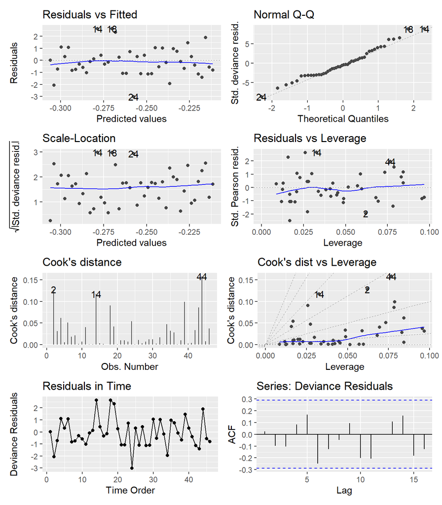

#### Logistic Regression on Proportions of Intense

```
Call:  glm(formula = cbind(Intense_Storms, Non_Intense) ~ YearsSinceStart,
    family = binomial, data = prop_data)

Coefficients:
    (Intercept)  YearsSinceStart
       -1.22270          0.01706

Degrees of Freedom: 45 Total (i.e. Null);  44 Residual
Null Deviance:      76.59
Residual Deviance: 71.07    AIC: 182.5
```

```
Single term deletions

Model:
cbind(Intense_Storms, Non_Intense) ~ YearsSinceStart
                Df Deviance    AIC    LRT Pr(>Chi)
<none>               71.072 182.53
YearsSinceStart  1   76.591 186.04 5.5186  0.01882 *
---
Signif. codes:  0 '***' 0.001 '**' 0.01 '*' 0.05 '.' 0.1 ' ' 1
```

That is a change of 3.4939884 percent per decade.

**Model Assessment**

The ratio of the residual deviance is 1.6152813.

The $p$-value for the Ljung-Box test on the deviance residuals 0.6302075.

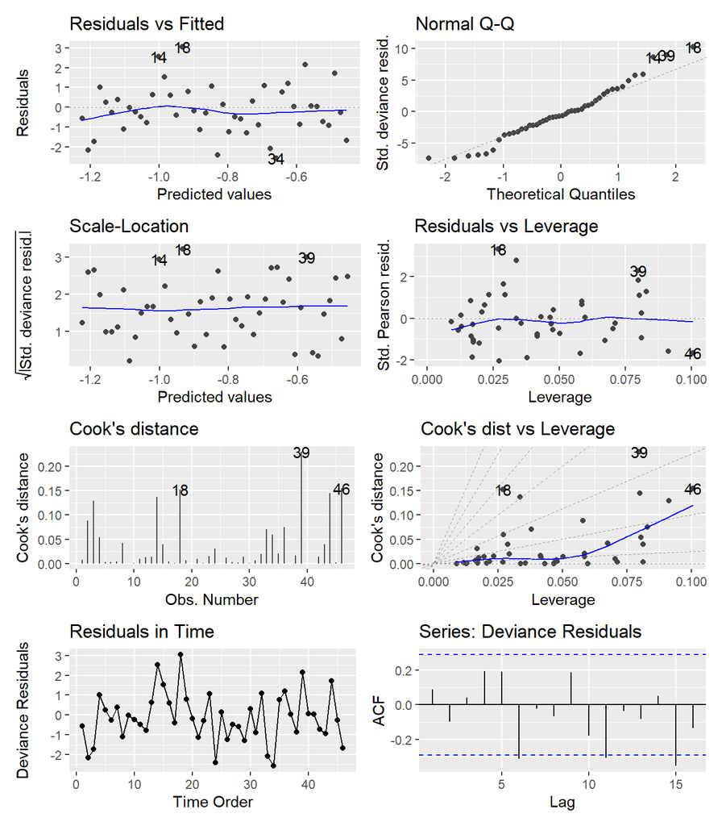

## HURSAT Quick Results

### Summary Statistics and Data

| Total Storms (Avg) | Total Storms (stddev) | Hurricanes (Avg) | Hurricanes (stddev) | Major Storms (Avg) | Major Storms (stddev) | Prop Major Storms | Intense Storms (Avg) | Intense Storms (stddev) | Prop Intense Storms |
| --- | --- | --- | --- | --- | --- | --- | --- | --- | --- |
| 8.863636 | 3.619013 | 8.181818 | 3.519201 | 5.431818 | 2.92859 | 0.6128205 | 3.772727 | 2.640152 | 0.425641 |

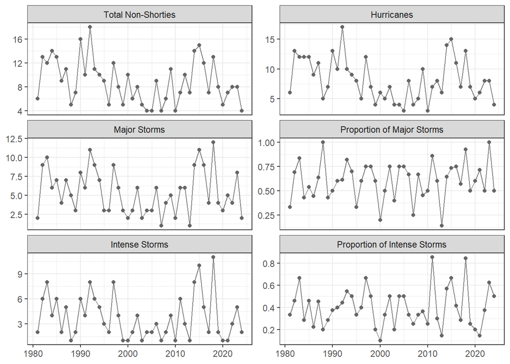

### Testing Results

**Changepoint Methods**

Here, we report the estimate mean for each segment or regime regardless of whether the test found a significant shift.

| Response | Chpt.Location | p.value | Regime1 | Regime2 | Change | Perc_Change |
| --- | --- | --- | --- | --- | --- | --- |
| Cyclone Freq | 1996 | 0.01462 | 10.93333 | 7.79310 | -3.14023 | -28.72161 |
| Hurricanes | 1998 | 0.01085 | 10.05882 | 7.00000 | -3.05882 | -30.40936 |
| Major Freq | 1995 | 0.14929 | 6.71429 | 4.83333 | -1.88095 | -28.01418 |
| Prop Major | 2014 | 0.67262 | 58.13149 | 70.29703 | 12.16554 | 20.92763 |
| Intense Freq | 1999 | 0.19207 | 4.55556 | 3.23077 | -1.32479 | -29.08068 |
| Prop Freq | 2011 | 0.93333 | 40.00000 | 48.00000 | 8.00000 | 20.00000 |

**Generalized Linear Model Approaches**

Note:

- we report the Likelihood Ratio Test for the generalized linear models, this is better to use than the default $Z$-test provided in the `summary()` output.
- the Change per decade is found by comparing the predicted value at the start time (1981) and end time (2024) and scaling by the number of years $\times 10$.

| Response | Coefficent | p.value | Start | End | Change per Decade |
| --- | --- | --- | --- | --- | --- |
| Cyclone Freq | -0.00883 | 0.02707 | 10.64994 | 7.28486 | -0.76479 |
| Hurricanes | -0.00881 | 0.03417 | 9.82597 | 6.72819 | -0.70404 |
| Major Freq | -0.00482 | 0.34461 | 6.01327 | 4.88828 | -0.25568 |
| Prop Major | 0.00992 | 0.21693 | 56.51116 | 66.56079 | 2.28401 |
| Intense Freq | -0.00565 | 0.35592 | 4.24881 | 3.33282 | -0.20818 |
| Prop Freq | 0.00528 | 0.50349 | 39.98748 | 45.53626 | 1.26109 |

## HURSAT Full Analysis

### Changepoint Methods

#### Change in Non-Shorty Counts

```
  SCUSUM Stat chpt Location       p-value
   0.68676891   15.00000000    0.01462332
```

The dates suggest the changepoint would occur from 1995 to 1996 with $p$-value 0.0146233.

In regime one, the mean number of storms is 10.9333333 (CI: 9.381747, 12.7415264) and in regime two, the mean number of storms is 7.7931034 (CI: 6.8405092, 8.8783538); a change of -3.1402299.

**Model Assessment**

The ratio of the residual deviance is 1.2456788.

The $p$-value for the Ljung-Box test on the deviance residuals 0.4973035.

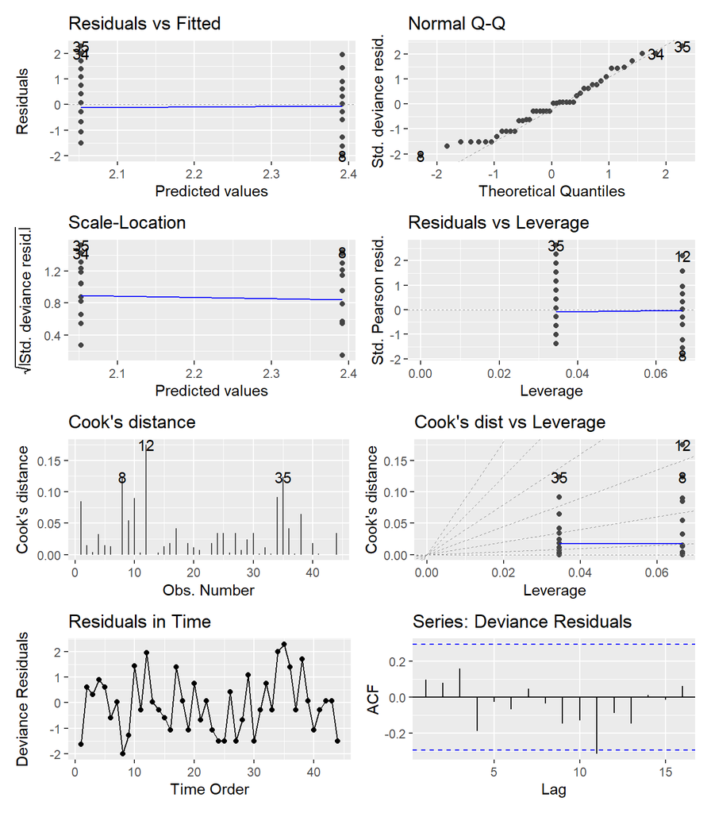

#### Change in counts of hurricanes

```
  SCUSUM Stat chpt Location       p-value
   0.73968090   17.00000000    0.01085252
```

The dates suggest the changepoint would occur from 1997 to 1998 with $p$-value 0.0108525.

In regime one, the mean number of hurricanes is 10.0588235 (CI: 8.6587062, 11.6853405) and in regime two, the mean number of hurricanes is 7 (CI: 6.0698976, 8.0726239); a change of -3.0588235.

**Model Assessment**

The ratio of the residual deviance is 1.2553161.

The $p$-value for the Ljung-Box test on the deviance residuals 0.3265414.

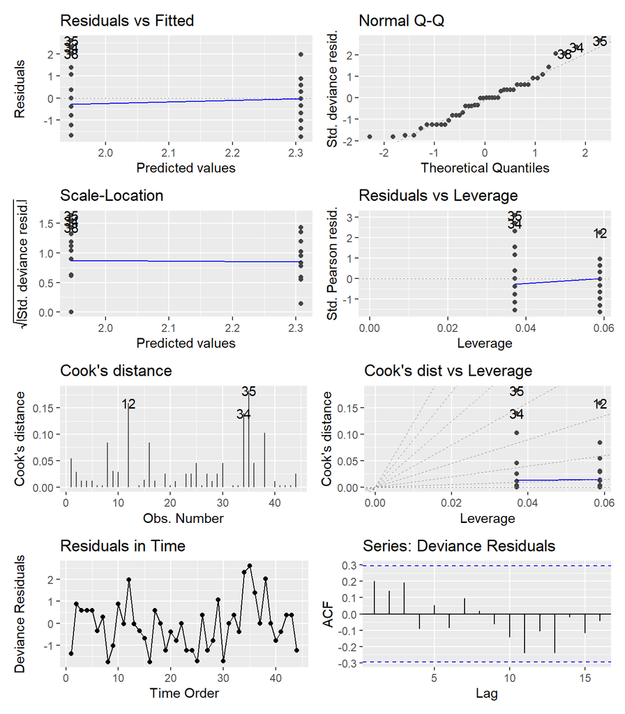

#### Change in counts of major storms

```
  SCUSUM Stat chpt Location       p-value
    0.2999228    14.0000000     0.1492858
```

The dates suggest the changepoint would occur from 1994 to 1995 with $p$-value 0.1492858.

In regime one, the mean number of storms is 6.7142857 (CI: 5.485339, 8.2185683) and in regime two, the mean number of storms is 4.8333333 (CI: 4.1073055, 5.6876975); a change of -1.8809524.

**Model Assessment**

The ratio of the residual deviance is 1.5036732.

The $p$-value for the Ljung-Box test on the deviance residuals 0.9295222.

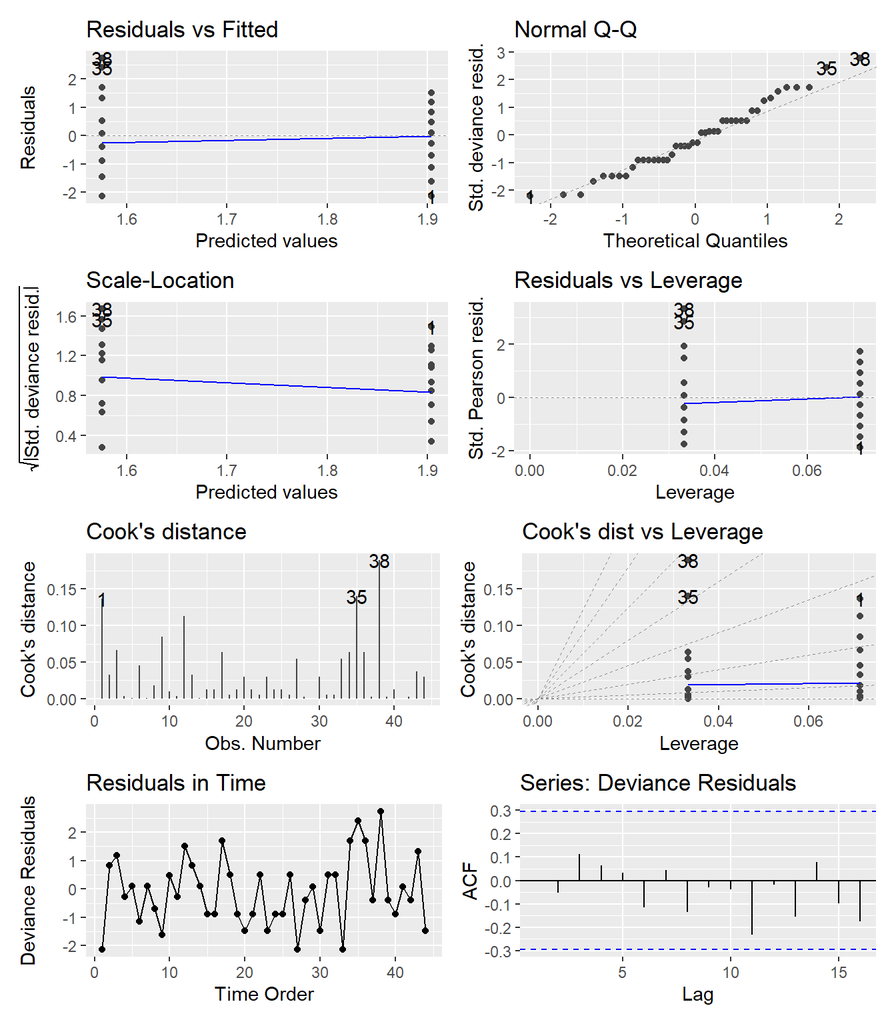

#### Change in counts of intense storms

```
  SCUSUM Stat chpt Location       p-value
    0.2624029    18.0000000     0.1920658
```

The dates suggest the changepoint would occur from 1998 to 1999 with $p$-value 0.1920658.

In regime one, the mean number of storms is 4.5555556 (CI: 3.668936, 5.6564319) and in regime two, the mean number of storms is 3.2307692 (CI: 2.6087384, 4.0011178); a change of -1.3247863.

**Model Assessment**

The ratio of the residual deviance is 1.6759927.

The $p$-value for the Ljung-Box test on the deviance residuals 0.8845167.

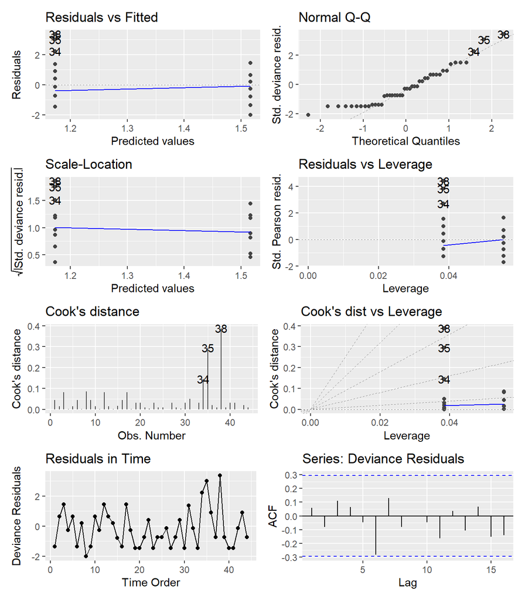

#### Proportion of major storms

A change in the proportion of major storms?

```
  SCUSUM Stat chpt Location       p-value
   0.07891514   33.00000000    0.67261688
```

The change in proportions occurs 2013 to 2014 with $p$-value 0.6726169.

In regime one, the proportion of major storms is 0.5813149 (CI: 0.5236009, 0.6368858) and in regime two, the proportion of major storms is 0.7029703 (CI: 0.6069907, 0.7838567); a change of 0.1216554.

**Model Assessment**

The ratio of the residual deviance is 1.3641836.

The $p$-value for the Ljung-Box test on the deviance residuals 0.1786476.

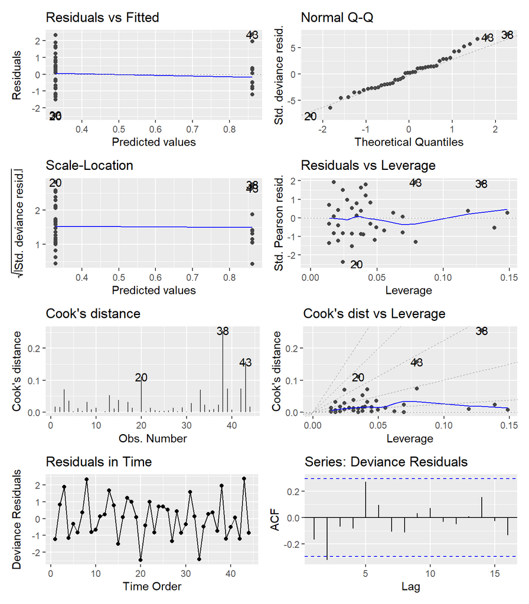

#### Proportion of intense storms

A change in the proportion of intense storms?

```
  SCUSUM Stat chpt Location       p-value
    0.0393654    30.0000000     0.9333314
```

The change in proportions occurs 2010 to 2011 with $p$-value 0.9333314.

In regime one, the proportion of intense storms is 0.4 (CI: 0.3427117, 0.4601604) and in regime two, the proportion of intense storms is 0.48 (CI: 0.3939021, 0.5673024); a change of 0.08.

**Model Assessment**

The ratio of the residual deviance is 1.1943337.

The $p$-value for the Ljung-Box test on the deviance residuals 0.3556382.

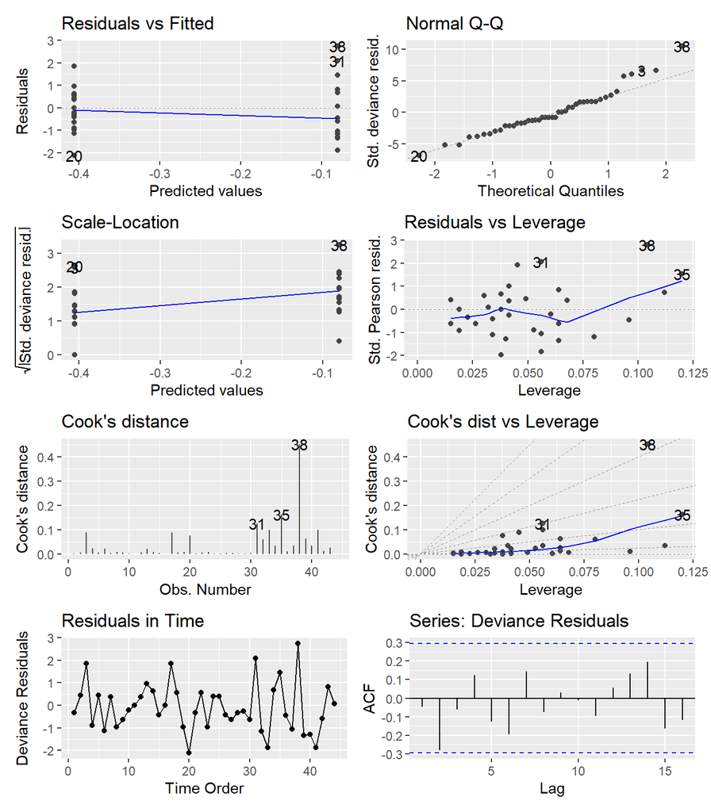

### Regression Methods

#### Poisson Regression on non-Shorties

```
Call:  glm(formula = Total_Storms ~ YearsSinceStart, family = poisson(link = "log"),
    data = storm_basin)

Coefficients:
    (Intercept)  YearsSinceStart
       2.365555        -0.008832

Degrees of Freedom: 43 Total (i.e. Null);  42 Residual
Null Deviance:      62.97
Residual Deviance: 58.09    AIC: 236.2
```

```
Single term deletions

Model:
Total_Storms ~ YearsSinceStart
                Df Deviance    AIC    LRT Pr(>Chi)
<none>               58.085 236.21
YearsSinceStart  1   62.972 239.10 4.8865  0.02707 *
---
Signif. codes:  0 '***' 0.001 '**' 0.01 '*' 0.05 '.' 0.1 ' ' 1
```

Using this model, in 1981 we would predict 10.6499444 storms (CI: 8.8407079, 12.8294383) and in 2024 we predict 7.2848618 storms (CI: 5.9322824, 8.9458335).

That is a change of -0.7647915 storms per decade.

**Model Assessment**

The ratio of the residual deviance is 1.3829825.

The $p$-value for the Ljung-Box test on the deviance residuals 0.1902607.

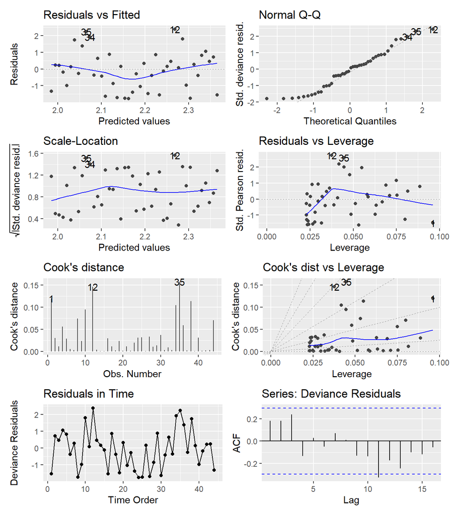

#### Poisson Regression on Hurricanes

```
Call:  glm(formula = Hurricanes ~ YearsSinceStart, family = poisson(link = "log"),
    data = storm_basin)

Coefficients:
    (Intercept)  YearsSinceStart
       2.285029        -0.008808

Degrees of Freedom: 43 Total (i.e. Null);  42 Residual
Null Deviance:      64.39
Residual Deviance: 59.9     AIC: 234.2
```

```
Single term deletions

Model:
Hurricanes ~ YearsSinceStart
                Df Deviance    AIC    LRT Pr(>Chi)
<none>               59.903 234.19
YearsSinceStart  1   64.389 236.67 4.4862  0.03417 *
---
Signif. codes:  0 '***' 0.001 '**' 0.01 '*' 0.05 '.' 0.1 ' ' 1
```

Using this model, in 1981 we would predict 9.8259748 hurricanes (CI: 8.0947471, 11.927461) and in 2024 we predict 6.7281925 hurricanes (CI: 5.4333825, 8.3315641).

That is a change of -0.7040414 hurricanes per decade.

**Model Assessment**

The ratio of the residual deviance is 1.4262548.

The $p$-value for the Ljung-Box test on the deviance residuals 0.0668395.

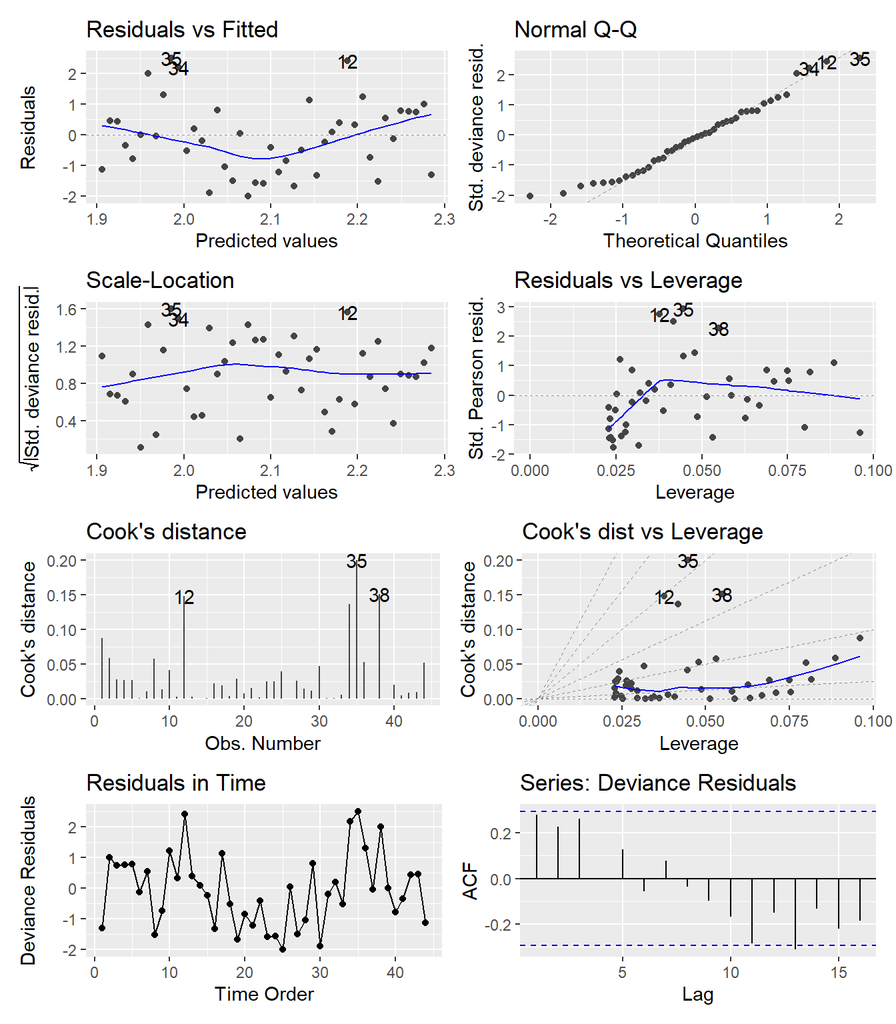

#### Poisson Regression on Major Storms

```
Call:  glm(formula = Major_Storms ~ YearsSinceStart, family = poisson(link = "log"),
    data = storm_basin)

Coefficients:
    (Intercept)  YearsSinceStart
       1.793968        -0.004817

Degrees of Freedom: 43 Total (i.e. Null);  42 Residual
Null Deviance:      69.15
Residual Deviance: 68.26    AIC: 222.2
```

```
Single term deletions

Model:
Major_Storms ~ YearsSinceStart
                Df Deviance    AIC     LRT Pr(>Chi)
<none>               68.256 222.19
YearsSinceStart  1   69.150 221.09 0.89321   0.3446
```

Using this model, in 1981 we would predict 6.0132666 major storms (CI: 4.7166949, 7.6662528) and in 2024 we predict 4.8882758 major storms (CI: 3.7833811, 6.3158427).

That is a change of -0.2556797 major storms per decade.

**Model Assessment**

The ratio of the residual deviance is 1.6251505.

The $p$-value for the Ljung-Box test on the deviance residuals 0.8426685.

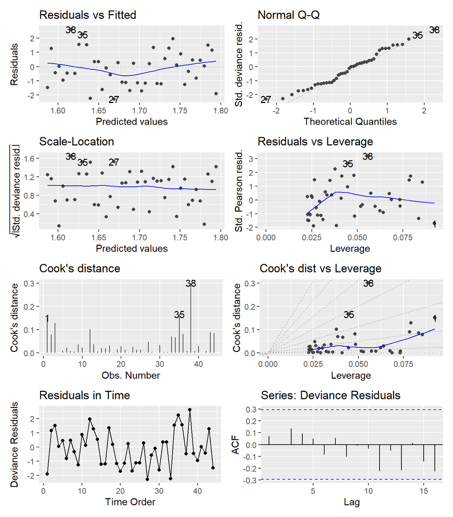

#### Poisson Regression on Intense Storms

```
Call:  glm(formula = Intense_Storms ~ YearsSinceStart, family = poisson(link = "log"),
    data = storm_basin)

Coefficients:
    (Intercept)  YearsSinceStart
       1.446638        -0.005647

Degrees of Freedom: 43 Total (i.e. Null);  42 Residual
Null Deviance:      75.26
Residual Deviance: 74.41    AIC: 209.8
```

```
Single term deletions

Model:
Intense_Storms ~ YearsSinceStart
                Df Deviance    AIC     LRT Pr(>Chi)
<none>               74.408 209.82
YearsSinceStart  1   75.261 208.68 0.85225   0.3559
```

Using this model, in 1981 we would predict 4.2488078 intense storms (CI: 3.1788103, 5.6789698) and in 2024 we predict 3.3328191 intense storms (CI: 2.4470615, 4.5391926).

That is a change of -0.2081792 intense storms per decade.

**Model Assessment**

The ratio of the residual deviance is 1.7716296.

The $p$-value for the Ljung-Box test on the deviance residuals 0.8263561.

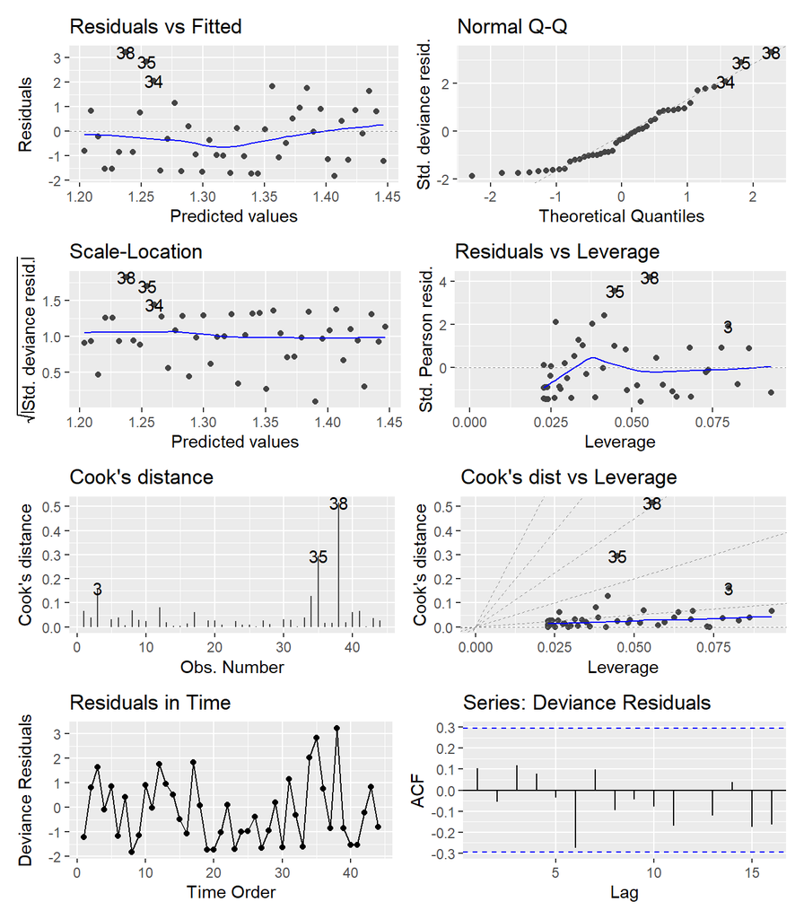

#### Logistic Regression on Proportions of Major

```
Call:  glm(formula = cbind(Major_Storms, Non_Major) ~ YearsSinceStart,
    family = binomial, data = prop_data)

Coefficients:
    (Intercept)  YearsSinceStart
       0.261934         0.009918

Degrees of Freedom: 43 Total (i.e. Null);  42 Residual
Null Deviance:      62.08
Residual Deviance: 60.55    AIC: 167.7
```

```
Single term deletions

Model:
cbind(Major_Storms, Non_Major) ~ YearsSinceStart
                Df Deviance    AIC    LRT Pr(>Chi)
<none>               60.554 167.66
YearsSinceStart  1   62.079 167.18 1.5246   0.2169
```

Using this model, in 1981 the probability of a major storm in was 0.5651116 (CI: 0.4725419, 0.653353) and in 2024 the probability of a major storm was 0.6656079 (CI: 0.5665483, 0.7519409).

That is a change of 2.2840061 percent per decade.

**Model Assessment**

The ratio of the residual deviance is 1.4417651.

The $p$-value for the Ljung-Box test on the deviance residuals 0.2886153.

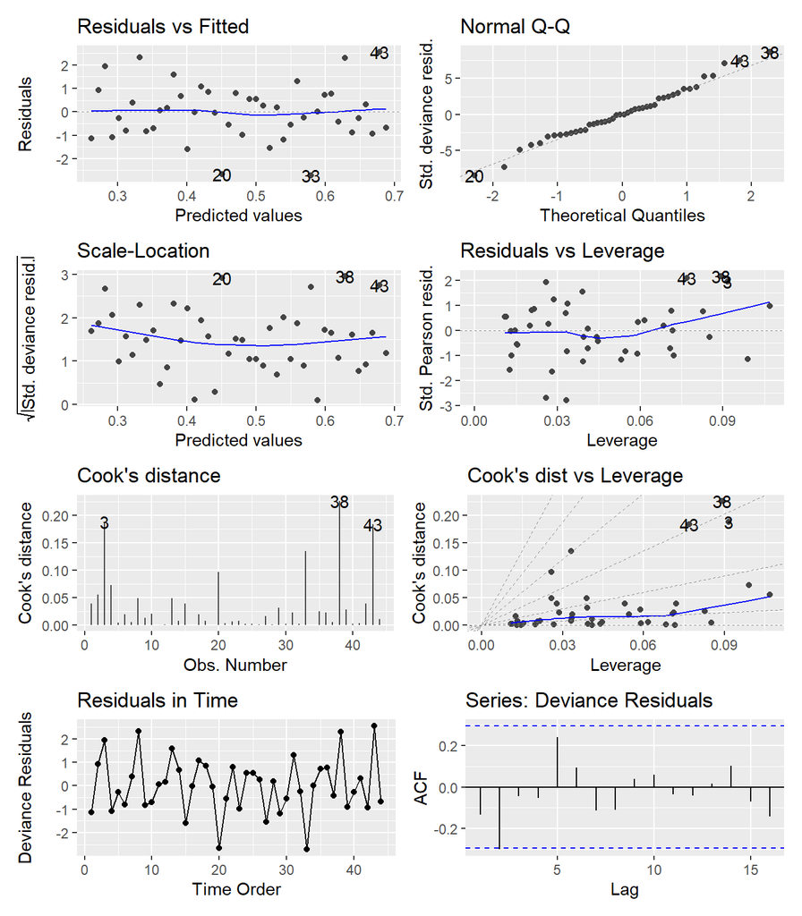

#### Logistic Regression on Proportions of Intense

```
Call:  glm(formula = cbind(Intense_Storms, Non_Intense) ~ YearsSinceStart,
    family = binomial, data = prop_data)

Coefficients:
    (Intercept)  YearsSinceStart
      -0.405987         0.005278

Degrees of Freedom: 43 Total (i.e. Null);  42 Residual
Null Deviance:      52.38
Residual Deviance: 51.93    AIC: 163.1
```

```
Single term deletions

Model:
cbind(Intense_Storms, Non_Intense) ~ YearsSinceStart
                Df Deviance    AIC     LRT Pr(>Chi)
<none>               51.929 163.08
YearsSinceStart  1   52.376 161.53 0.44756   0.5035
```

That is a change of 1.261086 percent per decade.

**Model Assessment**

The ratio of the residual deviance is 1.2363953.

The $p$-value for the Ljung-Box test on the deviance residuals 0.3704051.

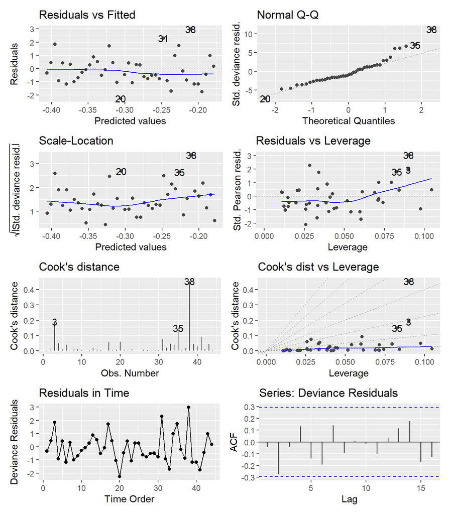

# Western North Pacific

## IBTrACS Quick Results

### Summary Statistics and Data

| Total Storms (Avg) | Total Storms (stddev) | Hurricanes (Avg) | Hurricanes (stddev) | Major Storms (Avg) | Major Storms (stddev) | Prop Major Storms | Intense Storms (Avg) | Intense Storms (stddev) | Prop Intense Storms |
| --- | --- | --- | --- | --- | --- | --- | --- | --- | --- |
| 17.73913 | 4.692475 | 14.84783 | 3.841107 | 8.673913 | 2.757248 | 0.4889706 | 6.76087 | 2.734023 | 0.3811275 |

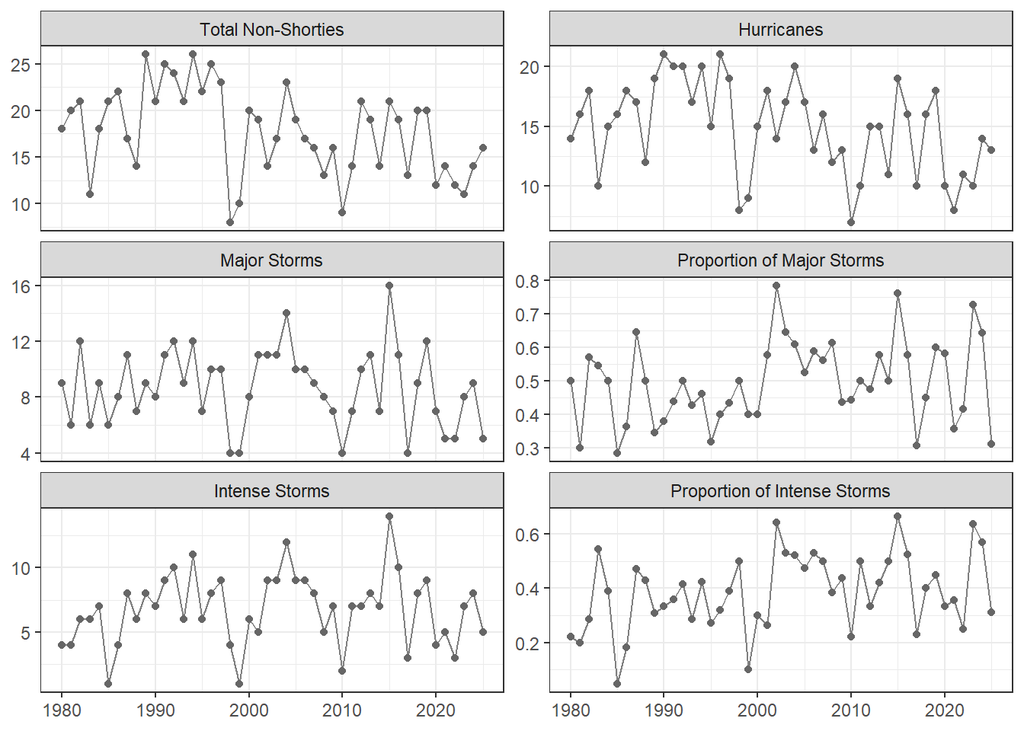

### Testing Results

**Changepoint Methods**

Here, we report the estimate mean for each segment or regime regardless of whether the test found a significant shift.

| Response | Chpt.Location | p.value | Regime1 | Regime2 | Change | Perc_Change |
| --- | --- | --- | --- | --- | --- | --- |
| Cyclone Freq | 1999 | 0.00219 | 20.83333 | 15.75000 | -5.08333 | -24.40000 |
| Hurricanes | 1999 | 0.00641 | 17.11111 | 13.39286 | -3.71825 | -21.73006 |
| Major Freq | 2018 | 0.69157 | 9.05405 | 7.11111 | -1.94294 | -21.45937 |
| Prop Major | 2002 | 0.07957 | 43.09927 | 54.83871 | 11.73944 | 27.23813 |
| Intense Freq | 1988 | 0.33921 | 4.57143 | 7.15385 | 2.58242 | 56.49038 |
| Prop Freq | 2003 | 0.00691 | 31.48148 | 45.57292 | 14.09144 | 44.76103 |

**Generalized Linear Model Approaches**

Note:

- we report the Likelihood Ratio Test for the generalized linear models, this is better to use than the default $Z$-test provided in the `summary()` output.
- the Change per decade is found by comparing the predicted value at the start time (1980) and end time (2025) and scaling by the number of years $\times 10$.

| Response | Coefficent | p.value | Start | End | Change per Decade |
| --- | --- | --- | --- | --- | --- |
| Cyclone Freq | -0.00776 | 0.00332 | 21.00943 | 14.82011 | -1.34550 |
| Hurricanes | -0.00754 | 0.00902 | 17.50415 | 12.46926 | -1.09454 |
| Major Freq | -0.00220 | 0.56014 | 9.10966 | 8.25199 | -0.18645 |
| Prop Major | 0.01136 | 0.03553 | 42.93758 | 55.64425 | 2.76232 |
| Intense Freq | 0.00322 | 0.45088 | 6.28246 | 7.26242 | 0.21304 |
| Prop Freq | 0.01858 | 0.00085 | 29.23220 | 48.79450 | 4.25267 |

## IBTrACS Full Analysis

### Changepoint Methods

#### Change in Non-Shorty Counts

```
  SCUSUM Stat chpt Location       p-value
  1.030001344  18.000000000   0.002194984
```

The dates suggest the changepoint would occur from 1998 to 1999 with $p$-value 0.002195.

In regime one, the mean number of storms is 20.8333333 (CI: 18.8279093, 23.0523619) and in regime two, the mean number of storms is 15.75 (CI: 14.3465147, 17.2907849); a change of -5.0833333.

**Model Assessment**

The ratio of the residual deviance is 0.9671321.

The $p$-value for the Ljung-Box test on the deviance residuals 0.4498497.

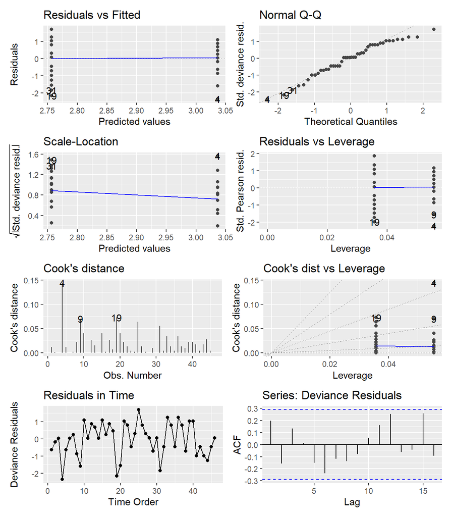

#### Change in counts of hurricanes

```
  SCUSUM Stat chpt Location       p-value
  0.834272862  18.000000000   0.006407271
```

The dates suggest the changepoint would occur from 1998 to 1999 with $p$-value 0.0064073.

In regime one, the mean number of hurricanes is 17.1111111 (CI: 15.3029659, 19.1329004) and in regime two, the mean number of hurricanes is 13.3928571 (CI: 12.1036561, 14.8193754); a change of -3.718254.

**Model Assessment**

The ratio of the residual deviance is 0.8382947.

The $p$-value for the Ljung-Box test on the deviance residuals 0.4435765.

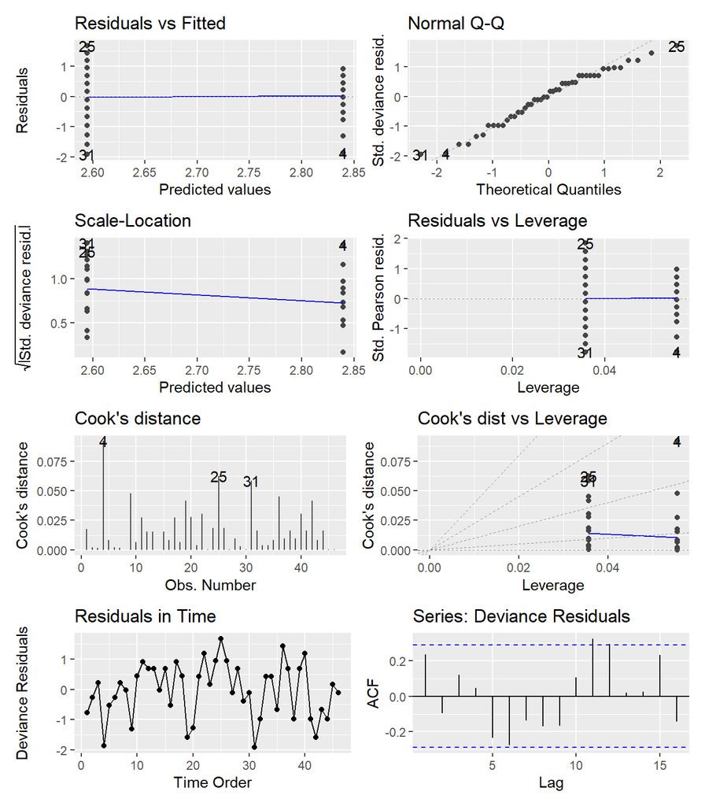

#### Change in counts of major storms

```
  SCUSUM Stat chpt Location       p-value
    0.1002678    37.0000000     0.6915678
```

The dates suggest the changepoint would occur from 2017 to 2018 with $p$-value 0.6915678.

In regime one, the mean number of storms is 9.0540541 (CI: 8.1345986, 10.0774357) and in regime two, the mean number of storms is 7.1111111 (CI: 5.5658998, 9.0853057); a change of -1.9429429.

**Model Assessment**

The ratio of the residual deviance is 0.8469793.

The $p$-value for the Ljung-Box test on the deviance residuals 0.8753242.

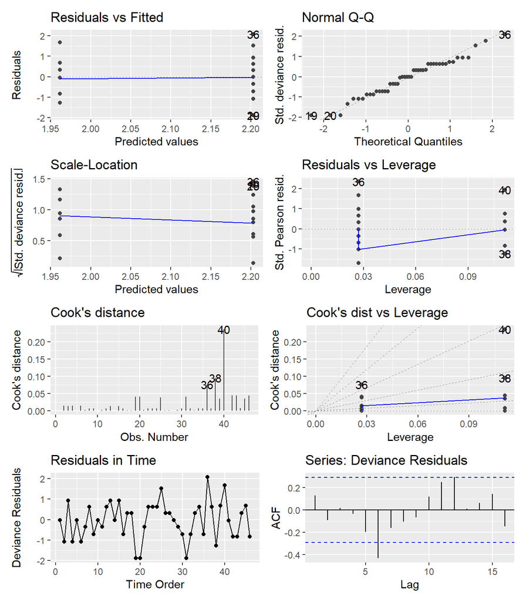

#### Change in counts of intense storms

```
  SCUSUM Stat chpt Location       p-value
    0.1834233     7.0000000     0.3392132
```

The dates suggest the changepoint would occur from 1987 to 1988 with $p$-value 0.3392132.

In regime one, the mean number of storms is 4.5714286 (CI: 3.2327881, 6.4643765) and in regime two, the mean number of storms is 7.1538462 (CI: 6.36178, 8.0445276); a change of 2.5824176.

**Model Assessment**

The ratio of the residual deviance is 1.1002203.

The $p$-value for the Ljung-Box test on the deviance residuals 0.681741.

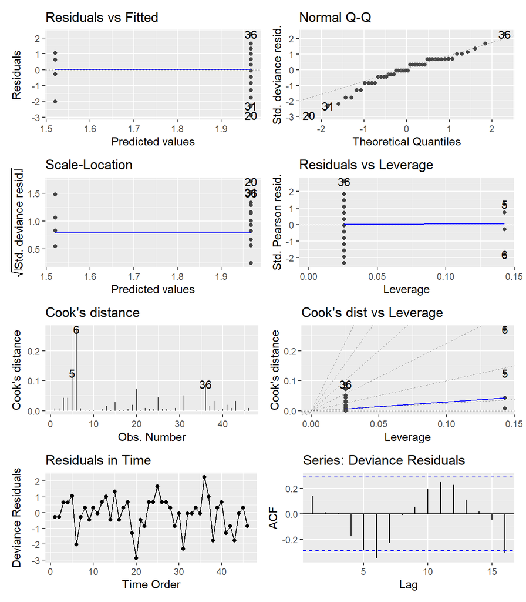

#### Proportion of major storms

A change in the proportion of major storms?

```
  SCUSUM Stat chpt Location       p-value
   0.39860342   21.00000000    0.07957283
```

The change in proportions occurs 2001 to 2002 with $p$-value 0.0795728.

In regime one, the proportion of major storms is 0.4309927 (CI: 0.3840114, 0.47925) and in regime two, the proportion of major storms is 0.5483871 (CI: 0.4994915, 0.596366); a change of 0.1173944.

**Model Assessment**

The ratio of the residual deviance is 0.841307.

The $p$-value for the Ljung-Box test on the deviance residuals 0.0090248.

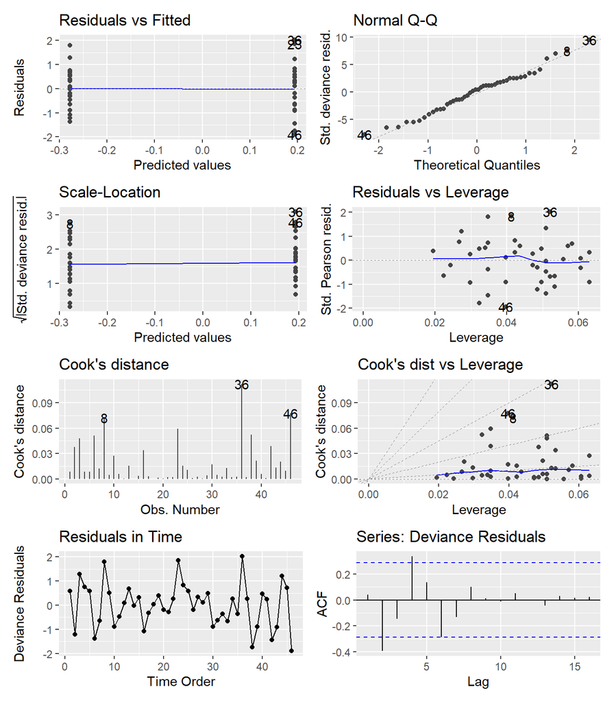

#### Proportion of intense storms

A change in the proportion of intense storms?

```
  SCUSUM Stat chpt Location       p-value
   0.82062206   22.00000000    0.00691053
```

The change in proportions occurs 2002 to 2003 with $p$-value 0.0069105.

In regime one, the proportion of intense storms is 0.3148148 (CI: 0.272744, 0.3601613) and in regime two, the proportion of intense storms is 0.4557292 (CI: 0.406518, 0.5058203); a change of 0.1409144.

**Model Assessment**

The ratio of the residual deviance is 1.0982608.

The $p$-value for the Ljung-Box test on the deviance residuals 0.0550746.

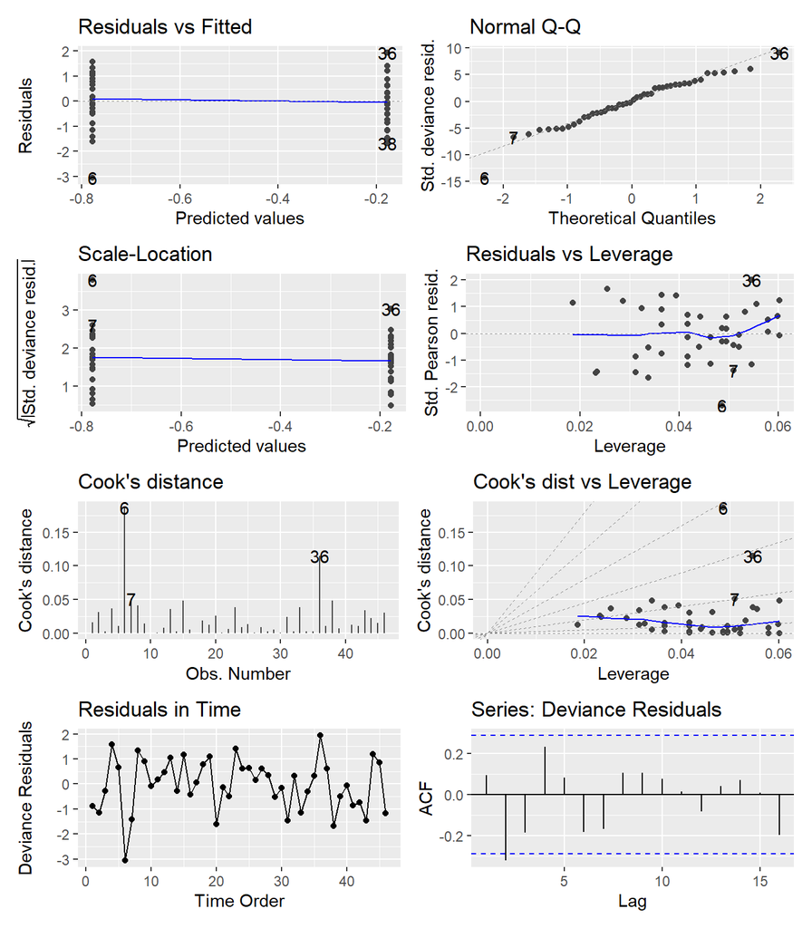

### Regression Methods

#### Poisson Regression on non-Shorties

```
Call:  glm(formula = Total_Storms ~ YearsSinceStart, family = poisson(link = "log"),
    data = storm_basin)

Coefficients:
    (Intercept)  YearsSinceStart
       3.044971        -0.007755

Degrees of Freedom: 45 Total (i.e. Null);  44 Residual
Null Deviance:      58.24
Residual Deviance: 49.62    AIC: 269.2
```

```
Single term deletions

Model:
Total_Storms ~ YearsSinceStart
                Df Deviance    AIC    LRT Pr(>Chi)
<none>               49.619 269.15
YearsSinceStart  1   58.241 275.77 8.6224  0.00332 **
---
Signif. codes:  0 '***' 0.001 '**' 0.01 '*' 0.05 '.' 0.1 ' ' 1
```

Using this model, in 1980 we would predict 21.0094317 storms (CI: 18.4613369, 23.9092231) and in 2025 we predict 14.8201141 storms (CI: 12.8649369, 17.0724337).

That is a change of -1.3455038 storms per decade.

**Model Assessment**

The ratio of the residual deviance is 1.1277.

The $p$-value for the Ljung-Box test on the deviance residuals 0.3931945.

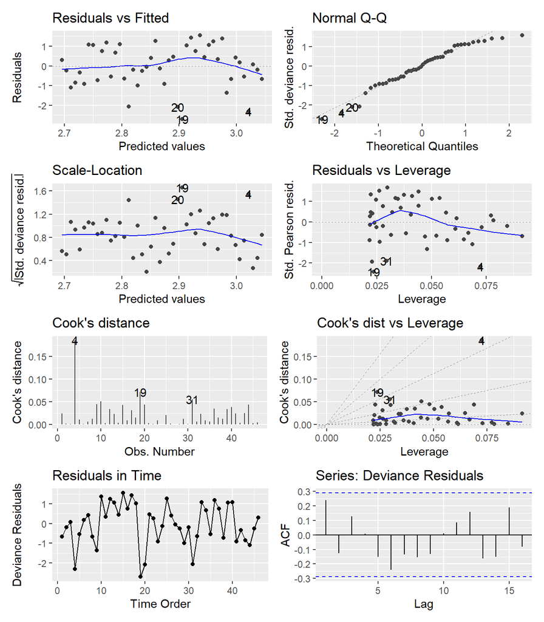

#### Poisson Regression on Hurricanes

```
Call:  glm(formula = Hurricanes ~ YearsSinceStart, family = poisson(link = "log"),
    data = storm_basin)

Coefficients:
    (Intercept)  YearsSinceStart
       2.862438        -0.007537

Degrees of Freedom: 45 Total (i.e. Null);  44 Residual
Null Deviance:      46.93
Residual Deviance: 40.11    AIC: 251.6
```

```
Single term deletions

Model:
Hurricanes ~ YearsSinceStart
                Df Deviance    AIC    LRT Pr(>Chi)
<none>               40.113 251.61
YearsSinceStart  1   46.931 256.43 6.8181 0.009024 **
---
Signif. codes:  0 '***' 0.001 '**' 0.01 '*' 0.05 '.' 0.1 ' ' 1
```

Using this model, in 1980 we would predict 17.5041538 hurricanes (CI: 15.1947621, 20.1645408) and in 2025 we predict 12.4692572 hurricanes (CI: 10.6849228, 14.5515675).

That is a change of -1.0945427 hurricanes per decade.

**Model Assessment**

The ratio of the residual deviance is 0.9116515.

The $p$-value for the Ljung-Box test on the deviance residuals 0.443524.

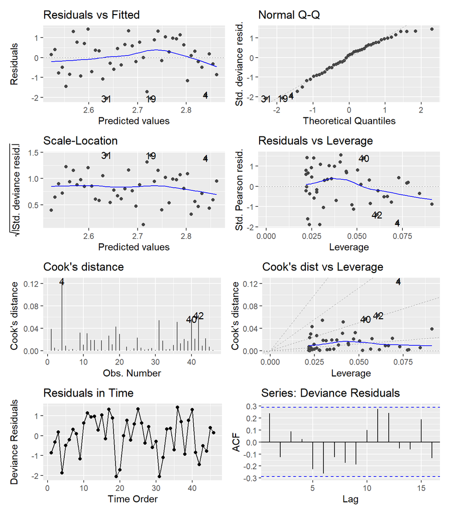

#### Poisson Regression on Major Storms

```
Call:  glm(formula = Major_Storms ~ YearsSinceStart, family = poisson(link = "log"),
    data = storm_basin)

Coefficients:
    (Intercept)  YearsSinceStart
       2.209335        -0.002197

Degrees of Freedom: 45 Total (i.e. Null);  44 Residual
Null Deviance:      40.58
Residual Deviance: 40.24    AIC: 226.6
```

```
Single term deletions

Model:
Major_Storms ~ YearsSinceStart
                Df Deviance    AIC     LRT Pr(>Chi)
<none>               40.237 226.62
YearsSinceStart  1   40.576 224.96 0.33946   0.5601
```

Using this model, in 1980 we would predict 9.1096571 major storms (CI: 7.5283064, 11.0231767) and in 2025 we predict 8.2519872 major storms (CI: 6.7859756, 10.0347093).

That is a change of -0.18645 major storms per decade.

**Model Assessment**

The ratio of the residual deviance is 0.9144772.

The $p$-value for the Ljung-Box test on the deviance residuals 0.8349967.

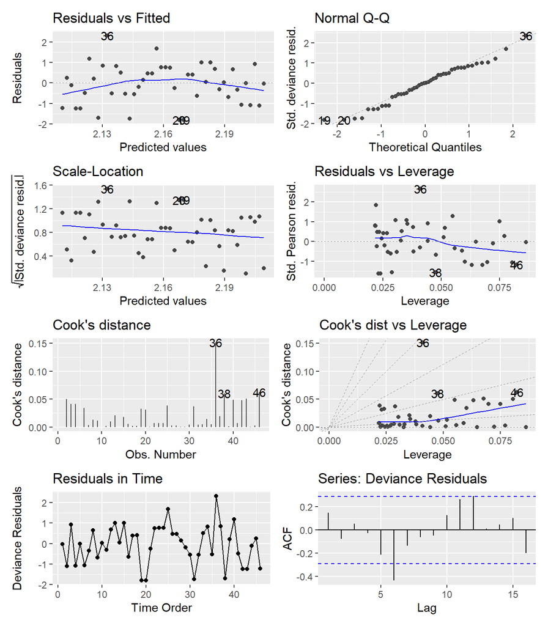

#### Poisson Regression on Intense Storms

```
Call:  glm(formula = Intense_Storms ~ YearsSinceStart, family = poisson(link = "log"),
    data = storm_basin)

Coefficients:
    (Intercept)  YearsSinceStart
       1.837761         0.003221

Degrees of Freedom: 45 Total (i.e. Null);  44 Residual
Null Deviance:      54.89
Residual Deviance: 54.32    AIC: 227.1
```

```
Single term deletions

Model:
Intense_Storms ~ YearsSinceStart
                Df Deviance    AIC     LRT Pr(>Chi)
<none>               54.323 227.10
YearsSinceStart  1   54.891 225.67 0.56843   0.4509
```

Using this model, in 1980 we would predict 6.2824554 intense storms (CI: 5.0271724, 7.8511821) and in 2025 we predict 7.2624244 intense storms (CI: 5.8591201, 9.0018307).

That is a change of 0.2130367 intense storms per decade.

**Model Assessment**

The ratio of the residual deviance is 1.2346055.

The $p$-value for the Ljung-Box test on the deviance residuals 0.5902662.

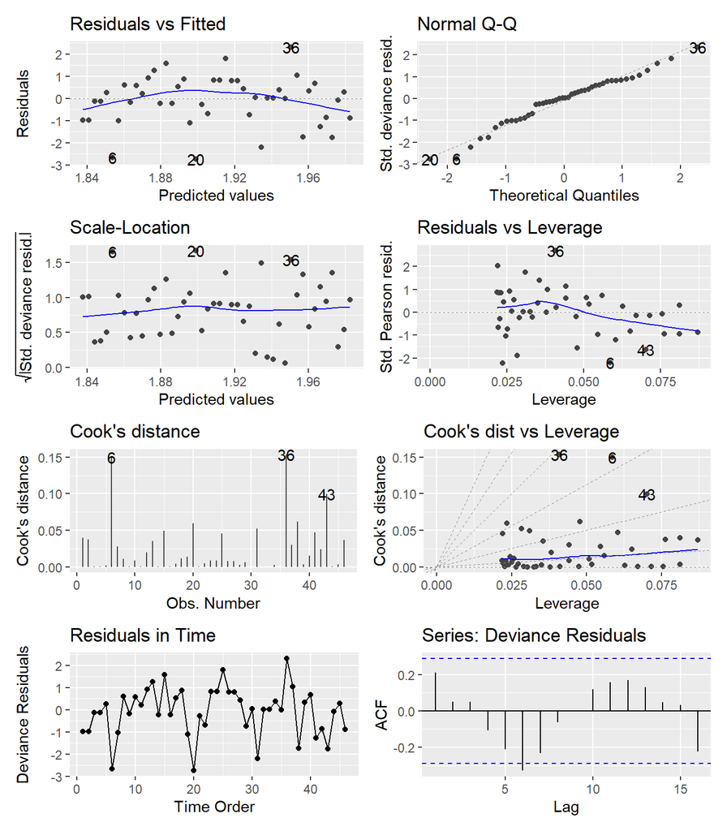

#### Logistic Regression on Proportions of Major

```
Call:  glm(formula = cbind(Major_Storms, Non_Major) ~ YearsSinceStart,
    family = binomial, data = prop_data)

Coefficients:
    (Intercept)  YearsSinceStart
       -0.28440          0.01136

Degrees of Freedom: 45 Total (i.e. Null);  44 Residual
Null Deviance:      48.29
Residual Deviance: 43.87    AIC: 197.8
```

```
Single term deletions

Model:
cbind(Major_Storms, Non_Major) ~ YearsSinceStart
                Df Deviance    AIC    LRT Pr(>Chi)
<none>               43.873 197.76
YearsSinceStart  1   48.293 200.18 4.4197  0.03553 *
---
Signif. codes:  0 '***' 0.001 '**' 0.01 '*' 0.05 '.' 0.1 ' ' 1
```

Using this model, in 1980 the probability of a major storm in was 0.4293758 (CI: 0.3663525, 0.4947752) and in 2025 the probability of a major storm was 0.5564425 (CI: 0.4846882, 0.6259167).

That is a change of 2.7623191 percent per decade.

**Model Assessment**

The ratio of the residual deviance is 0.9971092.

The $p$-value for the Ljung-Box test on the deviance residuals 0.0531883.

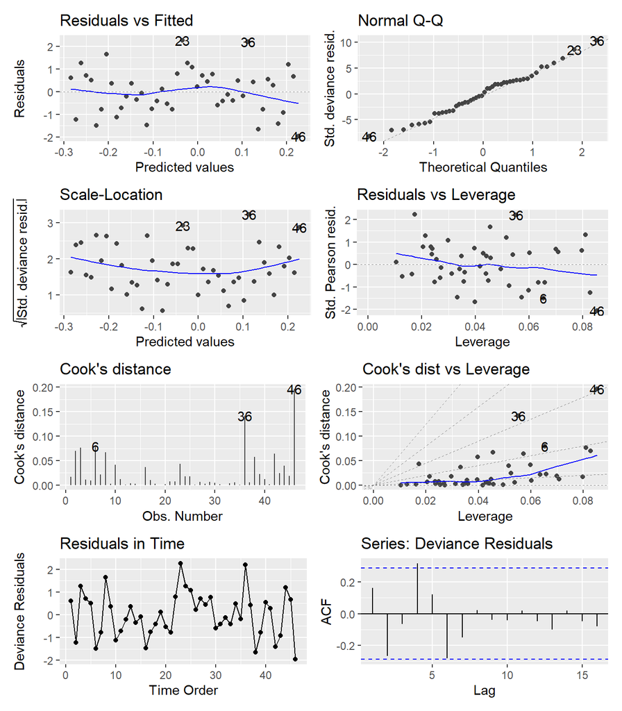

#### Logistic Regression on Proportions of Intense

```
Call:  glm(formula = cbind(Intense_Storms, Non_Intense) ~ YearsSinceStart,
    family = binomial, data = prop_data)

Coefficients:
    (Intercept)  YearsSinceStart
       -0.88413          0.01858

Degrees of Freedom: 45 Total (i.e. Null);  44 Residual
Null Deviance:      65.47
Residual Deviance: 54.34    AIC: 203.8
```

```
Single term deletions

Model:
cbind(Intense_Storms, Non_Intense) ~ YearsSinceStart
                Df Deviance    AIC    LRT Pr(>Chi)
<none>               54.341 203.78
YearsSinceStart  1   65.465 212.90 11.124 0.000852 ***
---
Signif. codes:  0 '***' 0.001 '**' 0.01 '*' 0.05 '.' 0.1 ' ' 1
```

That is a change of 4.2526733 percent per decade.

**Model Assessment**

The ratio of the residual deviance is 1.2350138.

The $p$-value for the Ljung-Box test on the deviance residuals 0.1392717.

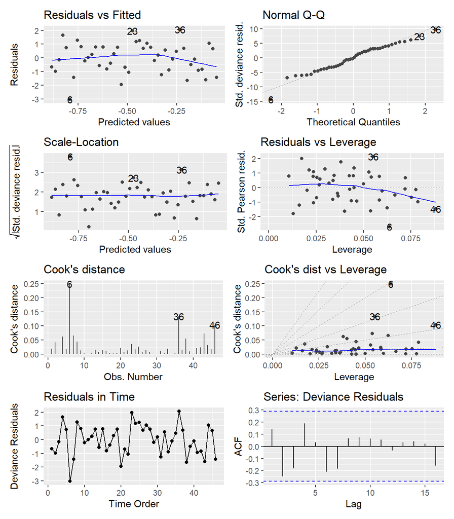

## HURSAT Quick Results

### Summary Statistics and Data

| Total Storms (Avg) | Total Storms (stddev) | Hurricanes (Avg) | Hurricanes (stddev) | Major Storms (Avg) | Major Storms (stddev) | Prop Major Storms | Intense Storms (Avg) | Intense Storms (stddev) | Prop Intense Storms |
| --- | --- | --- | --- | --- | --- | --- | --- | --- | --- |
| 15.09091 | 3.874893 | 12 | 3.242164 | 9.25 | 2.997092 | 0.6129518 | 6.409091 | 2.764544 | 0.4246988 |

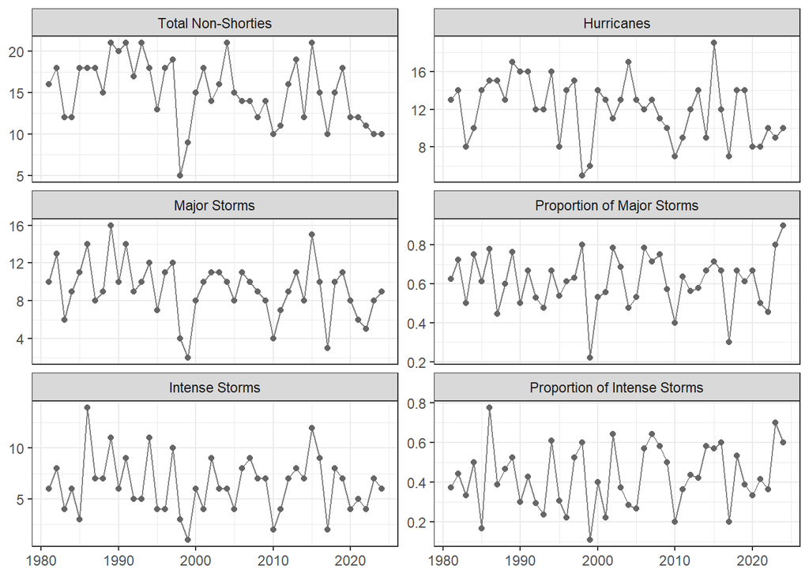

### Testing Results

**Changepoint Methods**

Here, we report the estimate mean for each segment or regime regardless of whether the test found a significant shift.

| Response | Chpt.Location | p.value | Regime1 | Regime2 | Change | Perc_Change |
| --- | --- | --- | --- | --- | --- | --- |
| Cyclone Freq | 1998 | 0.01434 | 17.35294 | 13.66667 | -3.68627 | -21.24294 |
| Hurricanes | 1998 | 0.09227 | 13.41176 | 11.11111 | -2.30065 | -17.15400 |
| Major Freq | 1998 | 0.08828 | 10.64706 | 8.37037 | -2.27669 | -21.38326 |
| Prop Major | 2023 | 0.86156 | 60.55901 | 85.00000 | 24.44099 | 40.35897 |
| Intense Freq | 1995 | 0.56292 | 7.28571 | 6.00000 | -1.28571 | -17.64706 |
| Prop Freq | 2006 | 0.27441 | 38.97059 | 48.04688 | 9.07629 | 23.29009 |

**Generalized Linear Model Approaches**

Note:

- we report the Likelihood Ratio Test for the generalized linear models, this is better to use than the default $Z$-test provided in the `summary()` output.
- the Change per decade is found by comparing the predicted value at the start time (1981) and end time (2024) and scaling by the number of years $\times 10$.

| Response | Coefficent | p.value | Start | End | Change per Decade |
| --- | --- | --- | --- | --- | --- |
| Cyclone Freq | -0.00765 | 0.01238 | 17.70666 | 12.74075 | -1.12861 |
| Hurricanes | -0.00626 | 0.06818 | 13.68453 | 10.45667 | -0.73361 |
| Major Freq | -0.00726 | 0.06333 | 10.76628 | 7.88011 | -0.65595 |
| Prop Major | 0.00106 | 0.86854 | 60.78566 | 61.86469 | 0.24523 |
| Intense Freq | -0.00312 | 0.50544 | 6.84892 | 5.98808 | -0.19565 |
| Prop Freq | 0.00815 | 0.19574 | 38.47276 | 47.02988 | 1.94480 |

## HURSAT Full Analysis

### Changepoint Methods

#### Change in Non-Shorty Counts

```
  SCUSUM Stat chpt Location       p-value
   0.69027557   17.00000000    0.01433589
```

The dates suggest the changepoint would occur from 1997 to 1998 with $p$-value 0.0143359.

In regime one, the mean number of storms is 17.3529412 (CI: 15.4815099, 19.4505943) and in regime two, the mean number of storms is 13.6666667 (CI: 12.3409903, 15.134748); a change of -3.6862745.

**Model Assessment**

The ratio of the residual deviance is 0.8565979.

The $p$-value for the Ljung-Box test on the deviance residuals 0.4545895.

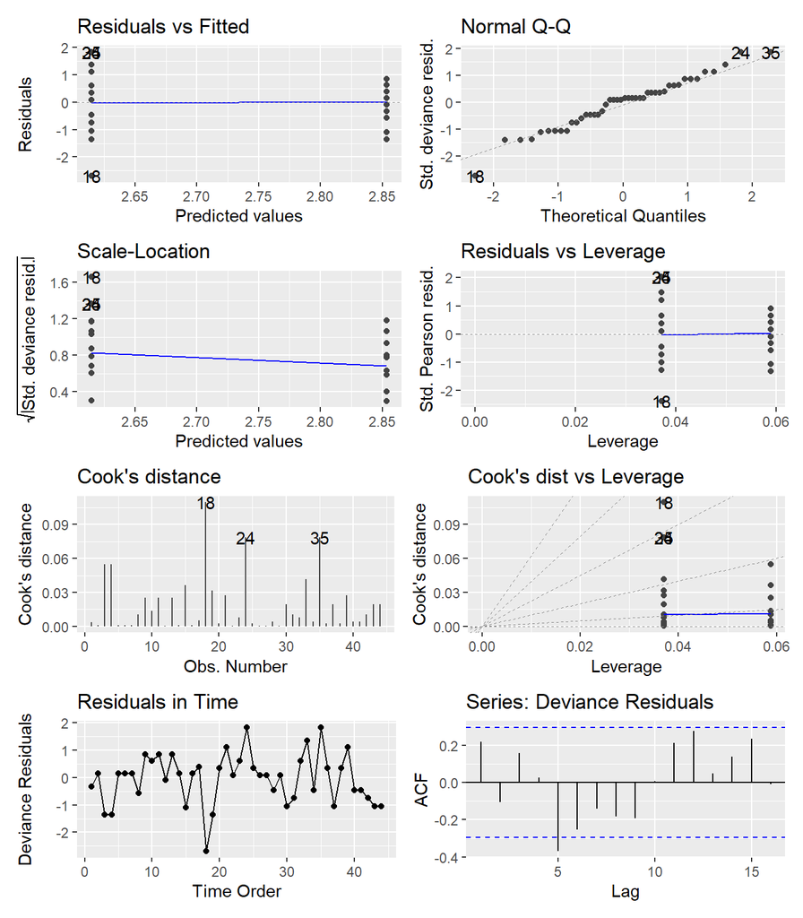

#### Change in counts of hurricanes

```
  SCUSUM Stat chpt Location       p-value
   0.37482782   17.00000000    0.09227292
```

The dates suggest the changepoint would occur from 1997 to 1998 with $p$-value 0.0922729.

In regime one, the mean number of hurricanes is 13.4117647 (CI: 11.7791158, 15.2707076) and in regime two, the mean number of hurricanes is 11.1111111 (CI: 9.9223023, 12.4423533); a change of -2.3006536.

**Model Assessment**

The ratio of the residual deviance is 0.8319579.

The $p$-value for the Ljung-Box test on the deviance residuals 0.3098896.

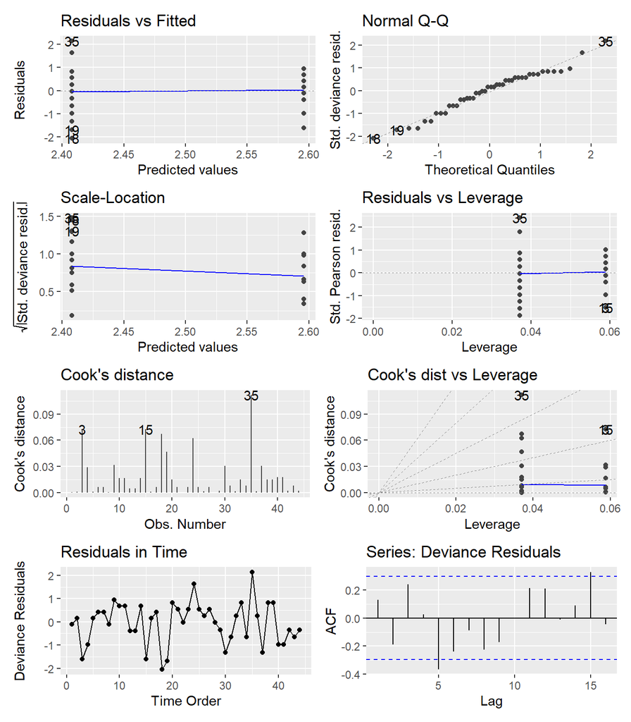